# Chemistry-Based Analysis: Sulfides, Selenides, and Tellurides

ECon NN Diagnosis & Weighted CN Analysis

crystract Workflow

2026-10-29

## Interactive manuscript figures

Figure 3 · Figure 4(a) · Figure 4(b) · Figure 5 · Figure 6

Hover over points to inspect the contributing records. Use the Plotly controls to zoom or reset the view.

## 1. Introduction

This notebook includes both the baseline **ECon Coordination Number** (which evaluates the geometric and effective environment without occupancy adjustments) and the **Weighted Coordination Number (WCN)**. Weighted CN provides a secondary, critical representation of the local chemical environment by taking into account crystallographic site occupancies to resolve the partial occupancies inherent to structural disorder. Both are provided for a comprehensive comparison, with a special focus on S, Se, and Te.

## 2. Setup: Libraries and Reference Data

We begin by loading the necessary data manipulation, crystallography, and parallel processing packages. A robust periodic table reference (`ptable`) and custom covalent radii are established to ensure accurate normalization and visualization.

```r
# Data Manipulation
library(data.table)
library(stringr)
library(tidyr)
library(dplyr)

# Crystallography
library(crystract)

# Parallel Processing
library(future)
library(future.apply)

# Visualization & HTML Export
library(ggplot2)
library(forcats)
library(viridis)
library(gridExtra)
library(DT)           # For interactive tables
library(plotly)       # For interactive plots
library(scales)       # For plot scales and breaks
library(htmlwidgets)  # For exporting interactive plots

# --- Initialize Time Tracking ---
timing_log <- data.frame(
  Step = character(),
  Duration_Mins = numeric(),
  stringsAsFactors = FALSE
)

log_time <- function(step_name, start_time) {
  duration <- as.numeric(difftime(Sys.time(), start_time, units = "mins"))
  return(data.frame(Step = step_name, Duration_Mins = duration))
}

global_start <- Sys.time()

# --- Setup Plotly Export Directory ---
dir.create(params$output_dir, recursive = TRUE, showWarnings = FALSE)
export_dir_plotly <- file.path(params$output_dir, "plotly_exports")
if (!dir.exists(export_dir_plotly)) {
  dir.create(export_dir_plotly, recursive = TRUE)
}

# --- ATOMIC NUMBER LOOKUP (For Sorting) ---
ptable <- data.table(
  Symbol = c(
    "H", "He", "Li", "Be", "B", "C", "N", "O", "F", "Ne", "Na", "Mg", "Al", "Si",
    "P", "S", "Cl", "Ar", "K", "Ca", "Sc", "Ti", "V", "Cr", "Mn", "Fe", "Co", "Ni",
    "Cu", "Zn", "Ga", "Ge", "As", "Se", "Br", "Kr", "Rb", "Sr", "Y", "Zr", "Nb",
    "Mo", "Tc", "Ru", "Rh", "Pd", "Ag", "Cd", "In", "Sn", "Sb", "Te", "I", "Xe",
    "Cs", "Ba", "La", "Ce", "Pr", "Nd", "Pm", "Sm", "Eu", "Gd", "Tb", "Dy", "Ho",
    "Er", "Tm", "Yb", "Lu", "Hf", "Ta", "W", "Re", "Os", "Ir", "Pt", "Au", "Hg",
    "Tl", "Pb", "Bi", "Po", "At", "Rn", "Fr", "Ra", "Ac", "Th", "Pa", "U", "Np",
    "Pu", "Am", "Cm", "Bk", "Cf", "Es", "Fm"
  ),
  Z = 1:100
)

# --- Define Custom Radii Table ---
custom_radii_values <- data.table(
  Symbol = c(
    "Ac", "Ag", "Al", "Am", "Ar", "As", "At", "Au", "B", "Ba", "Be", "Bi", "Br", "C",
    "Ca", "Cd", "Ce", "Cl", "Cm", "Co", "Cr", "Cs", "Cu", "Dy", "Er", "Eu", "F", "Fe",
    "Fr", "Ga", "Gd", "Ge", "H", "He", "Hf", "Hg", "Ho", "I", "In", "Ir", "K", "Kr",
    "La", "Li", "Lu", "Mg", "Mn", "Mo", "N", "Na", "Nb", "Nd", "Ne", "Ni", "Np", "O",
    "Os", "P", "Pa", "Pb", "Pd", "Pm", "Po", "Pr", "Pt", "Pu", "Ra", "Rb", "Re", "Rh",
    "Rn", "Ru", "S", "Sb", "Sc", "Se", "Si", "Sm", "Sn", "Sr", "Ta", "Tb", "Tc", "Te",
    "Th", "Ti", "Tl", "Tm", "U", "V", "W", "Xe", "Y", "Yb", "Zn", "Zr"
  ),
  Radius = c(
    2.15, 1.45, 1.21, 1.8, 1.06, 1.19, 1.5, 1.36, 0.84, 2.15, 0.96, 1.48, 1.2, 0.73,
    1.76, 1.44, 2.04, 1.02, 1.69, 1.38, 1.39, 2.44, 1.32, 1.92, 1.89, 1.98, 0.57, 1.42,
    2.6, 1.22, 1.96, 1.2, 0.31, 0.28, 1.75, 1.32, 1.92, 1.39, 1.42, 1.41, 2.03, 1.16,
    2.07, 1.28, 1.87, 1.41, 1.5, 1.54, 0.71, 1.66, 1.64, 2.01, 0.58, 1.24, 1.9, 0.66,
    1.44, 1.07, 2, 1.46, 1.39, 1.99, 1.4, 2.03, 1.36, 1.87, 2.21, 2.2, 1.51, 1.42, 1.5,
    1.46, 1.05, 1.39, 1.7, 1.2, 1.11, 1.98, 1.39, 1.95, 1.7, 1.94, 1.47, 1.38, 2.06,
    1.6, 1.45, 1.9, 1.96, 1.53, 1.62, 1.4, 1.9, 1.87, 1.22, 1.75
  ),
  Type = "covalent"
)
```

## 3. Data Discovery and Chemistry Filtering

To analyze Chalcogenides only, our filtering logic is: **(Contains S OR Se OR Te) AND (Does NOT contain O)**.

```r
# --- Configuration ---
cif_directory <- params$cif_directory

step_start <- Sys.time()

# --- 1. Get list of files ---
if (!dir.exists(cif_directory)) {
  warning("The specified directory does not exist. Please update 'cif_directory'.")
  all_cif_files <- character(0)
} else {
  all_cif_files <- list.files(cif_directory, pattern = "\\.cif$", full.names = TRUE)
}

if (length(all_cif_files) == 0)
  stop("No .cif files found.")

cat(sprintf(
  "Found %d CIF files. Checking coordinate chemistry...\n",
  length(all_cif_files)
))
```

```
## Found 1045 CIF files. Checking coordinate chemistry...
```

```r
# --- 2. Define Chemistry Filter Logic ---
check_chemistry <- function(file_path) {
  tryCatch({
    cif_content <- read_cif_files(file_path)[[1]]
    formula_str <- extract_chemical_formula(cif_content)

    # NEW: Extract database code while the file is already parsed in memory
    db_code <- extract_database_code(cif_content)

    # Check actual atomic coordinates in files
    atoms <- extract_atomic_coordinates(cif_content, formula_str)
    if (is.null(atoms) || nrow(atoms) == 0) {
      return(
        data.table(
          File = basename(file_path),
          Path = file_path,
          Keep = FALSE,
          Elements = NA_character_,
          Database_Code = db_code
        )
      )
    }

    # Extract letters at the start of the atom labels (e.g., 'Fe1' -> 'Fe')
    site_labels <- atoms$Label
    site_syms <- stringr::str_extract(site_labels, "^[A-Za-z]+")
    site_elements <- unique(stringr::str_to_title(site_syms))

    # Validate only against the Periodic Table (ignores random artifact labels)
    valid_elements <- intersect(site_elements, ptable$Symbol)

    # Criteria: Has S/Se/Te AND No Oxygen
    has_target <- any(c("S", "Se", "Te") %in% valid_elements)
    has_oxygen <- "O" %in% valid_elements

    keep <- has_target && !has_oxygen

    return(
      data.table(
        File = basename(file_path),
        Path = file_path,
        Keep = keep,
        Elements = paste(sort(valid_elements), collapse = ", "),
        Database_Code = db_code
      )
    )
  }, error = function(e) {
    return(
      data.table(
        File = basename(file_path),
        Path = file_path,
        Keep = FALSE,
        Elements = "Error",
        Database_Code = "Read Error"
      )
    )
  })
}

# --- 3. Run Filter (Parallelized) ---
plan(multisession, workers = params$workers)
filter_results <- rbindlist(future_lapply(all_cif_files, check_chemistry, future.seed = TRUE))
plan(sequential)

# Extract only the target files that passed the logic
target_files <- filter_results[Keep == TRUE]$Path

timing_log <- rbind(timing_log, log_time("1. Filtering", step_start))
cat(sprintf("Filtering complete. Kept: %d files.\n", length(target_files)))
```

```
## Filtering complete. Kept: 1045 files.
```

### 3.1 Included Chalcogenide Files Summary

This table displays every file that successfully bypassed the filter, alongside a comma-separated list of the exact physical elements discovered at its coordinate sites to guarantee validity.

```r
if(nrow(filter_results[Keep == TRUE]) > 0) {
  included_files_dt <- filter_results[Keep == TRUE, .(File, Elements)]

  datatable(
    included_files_dt,
    filter = 'top',
    extensions = 'Buttons',
    options = list(
      pageLength = 10,
      autoWidth = TRUE,
      dom = 'Bfrtip',
      buttons = c('copy', 'csv', 'excel')
    ),
    caption = "Successfully Filtered Chalcogenide Files (Contains S/Se/Te, No O)"
  )
} else {
  cat("No files passed the coordinate chemistry filter.\n")
}
```

|  | File | Elements |
| --- | --- | --- |
| 1 | Acanthite__0010584.cif | Ag, S |
| 2 | Agmantinite__0021412.cif | Ag, Mn, S, Sn, Zn |
| 3 | Aguilarite__0019989.cif | Ag, S, Se, Te |
| 4 | Aikinite__0009395.cif | Bi, Cu, Pb, S |
| 5 | Aikinite__0010716.cif | Bi, Cu, Pb, S |
| 6 | Aktashite__0012465.cif | As, Cu, Hg, S |
| 7 | Aktashite__0018863.cif | As, Cu, Hg, S |
| 8 | Aktashite__0018891.cif | As, Cu, Hg, S |
| 9 | Alabandite__0007512.cif | Mn, S |
| 10 | Alabandite__0007513.cif | Mn, S |

[output cut: 1035 more lines]

### 3.2 Validation Against the IMA Mineral List via OpenMindat

We validate the chemical formulas of naturally occurring minerals against the official International Mineralogical Association (IMA) list prior to geometric analysis.

Using the `OpenMindat` package, we dynamically pull the most up-to-date IMA-approved mineral list. **This workflow exclusively evaluates natural minerals and discards synthetics.** Any CIF file that does not report a mineral name, or reports a name not found in the IMA database, is dropped.

Furthermore, because real CIFs report *empirical* analytical formulas (which include trace substitutions) and the IMA reports *ideal* formulas, an exact string match is impossible. Instead, we perform an **Essential Element Check**: the script extracts the elements from both formulas and drops any CIF that is missing a core elemental component required by the IMA (e.g., catching a Celestine CIF missing its Oxygen).

**Demo default:** The notebook reuses the saved mineral selection in `minerals_database_codes.csv` without contacting Mindat. To refresh the IMA validation, set `validated_mapping` to `null` and configure `MINDAT_API_TOKEN`.

```r
if (!is.null(params$validated_mapping)) {
  saved_selection <- fread(params$validated_mapping)
  target_files <- filter_results[Keep == TRUE & File %in% saved_selection$File, Path]
  ima_results <- data.table(Path = target_files, Mineral = NA_character_, Formula = NA_character_,
                            Keep_IMA = TRUE, Reason = "Previously curated selection; IMA validation not refreshed")
} else {
# Load required libraries
library(OpenMindat)
library(httr)
library(jsonlite)
library(data.table)

# -------------------------------------------------------------------
# Establish the API connection using your Mindat API token.
# Replace "YOUR_API_TOKEN" with your actual token string.
# -------------------------------------------------------------------
# API_TOKEN <- "YOUR_API_TOKEN"
API_TOKEN <- Sys.getenv("MINDAT_API_TOKEN")
if (!nzchar(API_TOKEN)) stop("Set MINDAT_API_TOKEN to refresh the IMA selection")
mindat_connection(API_TOKEN)

step_start <- Sys.time()
cat("Fetching ALL IMA minerals from Mindat.org API (handling pagination)...\n")

# 1. Fetch IMA list robustly using a pagination loop (OpenMindat package only grabs first page)
base_url <- "https://api.mindat.org/v1/minerals-ima/?page_size=1000"
all_ima_minerals <- list()
current_url <- base_url

while (!is.null(current_url)) {
  req <- httr::GET(url = current_url, httr::add_headers(Authorization = paste("Token", API_TOKEN)))

  parsed <- jsonlite::fromJSON(httr::content(req, "text", encoding = "UTF-8"),
                               simplifyVector = TRUE)

  if (!is.null(parsed$results) && is.data.frame(parsed$results)) {
    all_ima_minerals[[length(all_ima_minerals) + 1]] <- as.data.table(parsed$results)
  }

  current_url <- parsed$`next`
}

ima_database <- rbindlist(all_ima_minerals, fill = TRUE)
cat(sprintf(
  "Successfully flattened %d IMA minerals into a database.\n",
  nrow(ima_database)
))

# Helper function to extract mineral name safely from raw text lines
extract_mineral_name <- function(raw_lines) {
  match_line <- grep(
    "^_chemical_name_mineral|^_mineral_name",
    raw_lines,
    value = TRUE,
    ignore.case = TRUE
  )
  if (length(match_line) > 0) {
    # Remove the tag itself
    name <- sub("^\\S+\\s+", "", match_line[1])
    # Strip any quotes
    name <- gsub("['\"]", "", name)
    return(trimws(name))
  }
  return(NA_character_)
}

# Helper function to extract unique chemical elements from a formula string
get_elements <- function(form_str) {
  if (is.na(form_str) || form_str == "")
    return(character(0))
  # Remove HTML tags (e.g., <sub>31</sub> -> 31)
  clean_str <- gsub("<[^>]+>", "", form_str)
  # Extract elements (Capital letter followed by optional lowercase letter)
  elems <- unlist(regmatches(clean_str, gregexpr("[A-Z][a-z]?", clean_str)))
  return(unique(elems))
}

# 2. Define validation function for our filtered targets
check_ima <- function(file_path) {
  tryCatch({
    # A. Read raw text to safely parse the mineral name
    raw_lines <- readLines(file_path, warn = FALSE)
    mineral_str <- extract_mineral_name(raw_lines)

    # B. Read with crystract to parse the chemical formula
    cif_list <- read_cif_files(file_path)
    if (length(cif_list) == 0)
      stop("crystract returned empty list")
    formula_str <- extract_chemical_formula(cif_list[[1]])

    # Handle missing, empty, or placeholder mineral names
    if (is.null(mineral_str) ||
        trimws(mineral_str) == "" || mineral_str == "?") {
      mineral_str <- NA_character_
    }

    # Filtering Logic
    if (is.na(mineral_str)) {
      keep_file <- FALSE
      reason <- "Discarded: Synthetic or Unnamed (No mineral name reported)"
    } else {
      # Match against the IMA database (case insensitive)
      match_idx <- match(tolower(mineral_str), tolower(ima_database$name))

      if (is.na(match_idx)) {
        keep_file <- FALSE
        reason <- sprintf("Discarded: Mineral name '%s' not found in official IMA list",
                          mineral_str)
      } else {
        ima_form <- ima_database$ima_formula[match_idx]

        # Element Validation
        ima_elems <- get_elements(ima_form)
        cif_elems <- get_elements(formula_str)

        # Check if any required elements from the IMA formula are missing in the CIF
        missing_elems <- setdiff(ima_elems, cif_elems)

        if (length(missing_elems) > 0) {
          keep_file <- FALSE
          clean_ima_form <- gsub("<[^>]+>", "", ima_form)
          reason <- sprintf(
            "Discarded: Missing essential IMA elements (%s). CIF: %s | IMA: %s",
            paste(missing_elems, collapse = ","),
            formula_str,
            clean_ima_form
          )
        } else {
          keep_file <- TRUE
          reason <- "IMA Validated (Name & Essential Elements Match)"
        }
      }
    }

    return(
      data.table(
        Path = file_path,
        Mineral = mineral_str,
        Formula = formula_str,
        Keep_IMA = keep_file,
        Reason = reason
      )
    )
  }, error = function(e) {
    # Print exact error message if something genuinely fails
    return(
      data.table(
        Path = file_path,
        Mineral = NA_character_,
        Formula = NA_character_,
        Keep_IMA = FALSE,
        Reason = paste("Read Error:", e$message)
      )
    )
  })
}

# 3. Run validation on the target files
cat(sprintf(
  "Validating %d files against the IMA database...\n",
  length(target_files)
))

plan(multisession, workers = params$workers)
ima_results <- rbindlist(future_lapply(target_files, check_ima, future.seed = TRUE))
plan(sequential)

# 4. Update target_files for Section 4
target_files <- ima_results[Keep_IMA == TRUE]$Path

timing_log <- rbind(timing_log, log_time("1.5 IMA Validation", step_start))
cat(
  sprintf(
    "IMA Validation complete. Kept: %d naturally occurring, formula-verified files.\n",
    length(target_files)
  )
)
}
```

### 3.3 Repeated compositions and measurement studies

For the reduced analysis, publication titles containing `pressure` or `temperature` are excluded before retaining the most recent publication per composition. Composition keys are built from normalized elemental ratios in sum formulas (including grouped occupancies), rounded to six decimal places. Formulas that cannot be parsed are retained separately. This screening does not establish ambient measurement conditions and does not distinguish polymorphs of the same composition. The full selected dataset can be reproduced with `unique_compositions = FALSE`.

```r
source("../scripts/composition_key.R")
selection <- rbindlist(lapply(target_files, function(path) {
  lines <- readLines(path, warn = FALSE)
  cif <- read_cif_files(path)[[1]]
  formula <- extract_chemical_formula(cif)
  key <- composition_key(formula)
  if (is.na(key)) key <- paste0("unparsed:", basename(path))
  year_line <- grep("^_journal_year", lines, value = TRUE)
  year <- if (length(year_line)) as.integer(gsub("[^0-9]", "", year_line[1])) else NA_integer_
  title_start <- grep("^_publ_section_title", lines)
  title <- ""
  if (length(title_start)) {
    rest <- lines[seq.int(title_start[1], length(lines))]
    next_tag <- which(grepl("^_", rest[-1]))
    last <- if (length(next_tag)) next_tag[1] else length(rest)
    title <- paste(rest[seq_len(last)], collapse = " ")
  }
  data.table(Path = path, File = basename(path), Formula = formula, CompositionKey = key,
             Year = year, Title = title,
             MeasurementStudy = grepl("pressure|temperature", title, ignore.case = TRUE))
}))
selection[, Retained := TRUE]
if (isTRUE(params$unique_compositions)) {
  selection[MeasurementStudy == TRUE, Retained := FALSE]
  eligible <- selection[Retained == TRUE][order(is.na(Year), -Year, File)]
  keep <- eligible[!duplicated(CompositionKey), Path]
  selection[, Retained := Path %in% keep]
  stopifnot(!anyDuplicated(selection[Retained == TRUE, CompositionKey]),
            !any(selection[Retained == TRUE, MeasurementStudy]))
}
fwrite(selection, file.path(params$output_dir, "composition_selection.csv"))
target_files <- selection[Retained == TRUE, Path]
cat(sprintf("Composition screening retained %d of %d selected CIF records.\n", length(target_files), nrow(selection)))
```

```
## Composition screening retained 602 of 1045 selected CIF records.
```

### 3.3 IMA Validation Summary

This table shows the result of the OpenMindat IMA check. You can use the search bar to find specific formulas or sort by `Keep_IMA` to review files that were dropped due to formula mismatches (e.g., missing oxygen).

```r
if(nrow(ima_results) > 0) {
  datatable(
    ima_results[, .(File = basename(Path), Mineral, Formula, Keep_IMA, Reason)],
    filter = 'top',
    extensions = 'Buttons',
    options = list(
      pageLength = 10,
      autoWidth = TRUE,
      dom = 'Bfrtip',
      buttons = c('copy', 'csv', 'excel')
    ),
    caption = "OpenMindat IMA Validation Results (Filtering)"
  )
} else {
  cat("No files available for IMA validation.\n")
}
```

|  | File | Mineral | Formula | Keep_IMA | Reason |
| --- | --- | --- | --- | --- | --- |
| 1 | Acanthite__0010584.cif |  |  | True | Previously curated selection; IMA validation not refreshed |
| 2 | Agmantinite__0021412.cif |  |  | True | Previously curated selection; IMA validation not refreshed |
| 3 | Aguilarite__0019989.cif |  |  | True | Previously curated selection; IMA validation not refreshed |
| 4 | Aikinite__0009395.cif |  |  | True | Previously curated selection; IMA validation not refreshed |
| 5 | Aikinite__0010716.cif |  |  | True | Previously curated selection; IMA validation not refreshed |
| 6 | Aktashite__0012465.cif |  |  | True | Previously curated selection; IMA validation not refreshed |
| 7 | Aktashite__0018863.cif |  |  | True | Previously curated selection; IMA validation not refreshed |
| 8 | Aktashite__0018891.cif |  |  | True | Previously curated selection; IMA validation not refreshed |
| 9 | Alabandite__0007512.cif |  |  | True | Previously curated selection; IMA validation not refreshed |
| 10 | Alabandite__0007513.cif |  |  | True | Previously curated selection; IMA validation not refreshed |

[output cut: 1035 more lines]

## 4. Parallel Analysis (ECon Algorithm)

We run the `crystract` feature extraction using the `econ` bonding algorithm. This chunk expands the unit cell into a 3x3x3 supercell to ensure edge-atoms are correctly bonded to their periodic neighbors. A ghost filtering mechanism is also applied to handle duplicate distance measurements often created by crystallographic disorder.

```r
set_radii_data(custom_radii_values)
```

```
## Custom radii table has been set for the current R session.
```

```r
cat("Custom radii table successfully loaded for filtering.\n")
```

```
## Custom radii table successfully loaded for filtering.
```

```r
analysis_output_dir <- file.path(params$output_dir, "econ_batches")
num_workers <- params$workers

# --- Robust Worker Function ---
process_structure_robust <- function(file_path) {
  suppressMessages(set_radii_data(custom_radii_values))
  fname <- basename(file_path)
  unavailable <- function(reason) data.table(file_name = fname, filter_status = reason)

  tryCatch({
    # 1. Read and Extract
    cif_list <- read_cif_files(file_path)
    if (length(cif_list) == 0)
      return(unavailable("unreadable_cif"))
    cif_data <- cif_list[[1]]

    formula <- extract_chemical_formula(cif_data)
    atoms   <- extract_atomic_coordinates(cif_data, formula)
    metrics <- extract_unit_cell_metrics(cif_data)
    sym_ops <- extract_symmetry_operations(cif_data)

    if (is.null(atoms) ||
        is.null(metrics) || is.null(sym_ops))
      return(unavailable("missing_geometry"))

    # 2. Transform and Expand (3x3x3 Supercell)
    full_cell <- apply_symmetry_operations(atoms, sym_ops, metrics, tolerance = 1e-4)
    expanded  <- expand_transformed_coords(full_cell, expansion_factors = c(1, 1, 1))

    # 3. Calculate Raw Distances
    dists <- calculate_distances(atoms, expanded, metrics, tolerance = 1e-4)
    if (nrow(dists) == 0)
      return(unavailable("no_distances"))

    # --- 4. Attempt Ghost Filtering ---
    filter_status <- "applied"

    ghost_res <- tryCatch({
      filter_ghost_distances(dists, atoms, margin = 0.15, radii_type = "covalent")
    }, error = function(e) stop("Ghost filtering failed: ", conditionMessage(e)))

    clean_dists <- ghost_res$kept

    # 5. Determine Bonds using ECon
    bonds <- econ_nn(clean_dists, atoms)
    if (nrow(bonds) == 0)
      return(unavailable("no_bonds_after_filtering"))

    if (is.null(calculate_weighted_neighbor_counts(bonds, atoms)))
      return(unavailable("invalid_site_occupancy"))

    # 6. Calculate Properties
    cn_table <- calculate_neighbor_counts(bonds)
    angles   <- calculate_angles(bonds, atoms, expanded, metrics)

    # 7. Return Result
    data.table(
      file_name = fname,
      chemical_formula = formula,
      filter_status = filter_status,
      # Log status for diagnosis
      atomic_coordinates = list(atoms),
      expanded_coords = list(expanded),
      bonds_econ = list(bonds),
      angles_econ = list(angles),
      cn_econ = list(cn_table)
    )

  }, error = function(e) {
    warning(fname, ": ", conditionMessage(e))
    return(data.table(file_name = fname, filter_status = "error", error_message = conditionMessage(e)))
  })
}

# --- Execution Loop ---
step_start <- Sys.time()

if (length(target_files) > 0) {
  if (!dir.exists(analysis_output_dir))
    dir.create(analysis_output_dir, recursive = TRUE)
  batch_size  <- 500
  num_batches <- ceiling(length(target_files) / batch_size)

  plan(multisession, workers = num_workers)

  for (b in 1:num_batches) {
    idx_start <- (b - 1) * batch_size + 1
    idx_end   <- min(b * batch_size, length(target_files))
    batch_files <- target_files[idx_start:idx_end]

    cat(sprintf(
      "Processing Batch %d of %d (%d files)...\n",
      b,
      num_batches,
      length(batch_files)
    ))
    results_list <- future_lapply(batch_files, process_structure_robust, future.seed = TRUE)
    batch_dt <- rbindlist(results_list, fill = TRUE)

    if (nrow(batch_dt) > 0) {
      save_path <- file.path(analysis_output_dir, paste0("batch_", b, ".rds"))
      saveRDS(batch_dt, save_path)
      fwrite(batch_dt[, intersect(c("file_name", "filter_status", "error_message"), names(batch_dt)), with = FALSE],
             file.path(params$output_dir, paste0("batch_", b, "_status.csv")))

      # Print filter stats for this batch
      stats <- table(batch_dt$filter_status)
      cat("  Filter Status:",
          paste(
            names(stats),
            stats,
            sep = "=",
            collapse = ", "
          ),
          "\n")
    }
    rm(results_list, batch_dt)
    gc()
  }
  plan(sequential)
  timing_log <- rbind(timing_log, log_time("2. Analysis (Robust)", step_start))
} else {
  stop("No files passed the chemistry filter.")
}
```

```
## Processing Batch 1 of 2 (500 files)...
```

```
##   Filter Status: applied=492, invalid_site_occupancy=5, no_bonds_after_filtering=3
## Processing Batch 2 of 2 (102 files)...
```

```
##   Filter Status: applied=100, invalid_site_occupancy=1, no_bonds_after_filtering=1
```

## 5. Data Processing: Aggregation & Diagnosis

In this step, we collect the ECon output and map elemental data (Atomic Number, Covalent Radii) to the central and neighbor atoms. We compute the **Normalized Distance** for each bond by dividing the geometric distance by the sum of the covalent radii of the two bonded elements. Additionally, we compute the **Weighted Coordination Number (WCN)** by weighing the geometric instances against structural occupancy.

```r
step_start <- Sys.time()

final_bonds_list <- list()
final_angles_list <- list()
high_cn_debug_log <- list()
invalid_occupancy_files <- character()

if (dir.exists(analysis_output_dir)) {
  cat("Reading batch files and aggregating results...\n")
  batch_files <- list.files(analysis_output_dir,
                            pattern = "^batch_\\d+\\.rds$",
                            full.names = TRUE)

  for (bf in batch_files) {
    batch_dt <- readRDS(bf)
    if ("filter_status" %in% names(batch_dt)) batch_dt <- batch_dt[filter_status == "applied"]
    if (!nrow(batch_dt)) next

    for (i in seq_len(nrow(batch_dt))) {
      current_file <- batch_dt$file_name[i]
      if (is.null(batch_dt$bonds_econ) ||
          length(batch_dt$bonds_econ) < i)
        next

      bonded_pairs <- batch_dt$bonds_econ[[i]]
      angles       <- batch_dt$angles_econ[[i]]
      coords       <- batch_dt$atomic_coordinates[[i]]
      cn_table     <- batch_dt$cn_econ[[i]]
      expanded_coords <- batch_dt$expanded_coords[[i]]

      if (is.null(bonded_pairs) ||
          nrow(bonded_pairs) == 0 || is.null(coords))
        next
      coords <- unique(coords, by = "Label")

      # --- DIAGNOSE HIGH GEOMETRIC CN ---
      high_cn_atoms <- cn_table[CoordinationNumber > 12]
      if (nrow(high_cn_atoms) > 0) {
        bad_bonds <- bonded_pairs[Atom1 %in% high_cn_atoms$Atom]
        exp_coords_ref <- unique(expanded_coords[, .(Label,
                                                     x2 = x_a,
                                                     y2 = y_b,
                                                     z2 = z_c)], by = "Label")
        bad_bonds <- merge(
          bad_bonds,
          exp_coords_ref,
          by.x = "Atom2",
          by.y = "Label",
          all.x = TRUE
        )
        bad_bonds[, `:=`(
          x1 = x2 + DeltaX,
          y1 = y2 + DeltaY,
          z1 = z2 + DeltaZ
        )]
        bad_bonds[, `:=`(File = current_file, Total_CN = cn_table[match(Atom1, Atom), CoordinationNumber])]
        high_cn_debug_log[[length(high_cn_debug_log) + 1]] <- bad_bonds
      }

      # --- COLLECT ANGLES ---
      if (!is.null(angles) && nrow(angles) > 0) {
        angles[, file_name := current_file]
        final_angles_list[[length(final_angles_list) + 1]] <- angles
      }

      # --- CALCULATE WEIGHTED CN ---
      weighted_counts <- calculate_weighted_neighbor_counts(bonded_pairs, coords)
      if (is.null(weighted_counts)) {
        invalid_occupancy_files <- c(invalid_occupancy_files, current_file)
        # Remove this record's angles as well as its bonds.
        final_angles_list <- Filter(function(x) !identical(x$file_name[1], current_file), final_angles_list)
        next
      }
      bonded_pairs[, NeighborSite := sub("_.*", "", Atom2)]
      w_cn <- weighted_counts[, .(Atom1 = Atom, CN_Weighted = WeightedCoordinationNumber)]

      # --- ASSEMBLE DATA ---
      # Merge Exact Neighbor Occupancies into final dataset for Specific WCN plots
      bonded_pairs <- merge(
        bonded_pairs,
        coords[, .(Label, Occupancy)],
        by.x = "NeighborSite",
        by.y = "Label",
        all.x = TRUE
      )
      bonded_pairs[is.na(Occupancy), Occupancy := 1.0]

      bonded_pairs <- merge(bonded_pairs, w_cn, by = "Atom1")
      bonded_pairs[, `:=`(
        file_name = current_file,
        CoordinationNumber = cn_table[match(Atom1, Atom), CoordinationNumber],
        RoundedWeightedCN = round(CN_Weighted),
        Element1 = str_extract(Atom1, "^[A-Za-z]+"),
        Element2 = str_extract(Atom2, "^[A-Za-z]+")
      )]
      final_bonds_list[[length(final_bonds_list) + 1]] <- bonded_pairs
    }
  }

  final_bonds_data <- rbindlist(final_bonds_list, fill = TRUE)
  all_angles_data <- rbindlist(final_angles_list, fill = TRUE)
  high_cn_diagnosis <- rbindlist(high_cn_debug_log, fill = TRUE)

  if (!nrow(final_bonds_data)) stop("No bonds were produced; inspect the per-file error report")

  # Merge Atomic Numbers
  final_bonds_data <- merge(
    final_bonds_data,
    ptable,
    by.x = "Element1",
    by.y = "Symbol",
    all.x = TRUE
  )
  setnames(final_bonds_data, "Z", "Z1")
  final_bonds_data <- merge(
    final_bonds_data,
    ptable,
    by.x = "Element2",
    by.y = "Symbol",
    all.x = TRUE
  )
  setnames(final_bonds_data, "Z", "Z2")

  # Merge Custom Radii for Normalized Distance Calculation
  final_bonds_data <- merge(
    final_bonds_data,
    custom_radii_values[, .(Symbol, Radius)],
    by.x = "Element1",
    by.y = "Symbol",
    all.x = TRUE
  )
  setnames(final_bonds_data, "Radius", "Radius1")
  final_bonds_data <- merge(
    final_bonds_data,
    custom_radii_values[, .(Symbol, Radius)],
    by.x = "Element2",
    by.y = "Symbol",
    all.x = TRUE
  )
  setnames(final_bonds_data, "Radius", "Radius2")

  # Calculate Normalized Distance = Distance / (Radius1 + Radius2)
  final_bonds_data[, NormalizedDistance := Distance / (Radius1 + Radius2)]

  if (nrow(all_angles_data) > 0) {
    all_angles_data[, Element1 := str_extract(CentralAtom, "^[A-Za-z]+")]
    all_angles_data[, Element2 := str_extract(Neighbor1, "^[A-Za-z]+")]
    all_angles_data <- merge(
      all_angles_data,
      ptable,
      by.x = "Element1",
      by.y = "Symbol",
      all.x = TRUE
    )
    setnames(all_angles_data, "Z", "Z1")
    all_angles_data <- merge(
      all_angles_data,
      ptable,
      by.x = "Element2",
      by.y = "Symbol",
      all.x = TRUE
    )
    setnames(all_angles_data, "Z", "Z2")
  }

  timing_log <- rbind(timing_log, log_time("3. Process & Diagnose", step_start))

  final_bonds_data <- final_bonds_data[!is.na(Z1) & !is.na(Z2)]
  if (nrow(all_angles_data) > 0)
    all_angles_data <- all_angles_data[!is.na(Z1) & !is.na(Z2)]
  cat("Processing Complete.\n")
}
```

```
## Reading batch files and aggregating results...
## Processing Complete.
```

### 5.1 Diagnostics

This table allows us to peek into files where elements exhibited mathematically massive coordination numbers. Extremely high ECon CNs (> 12) usually indicate deeply disordered structures, overlapping atomic positions, or parsing errors.

```r
if (exists("high_cn_diagnosis") &&
    nrow(high_cn_diagnosis) > 0) {
  datatable(head(high_cn_diagnosis[order(-Total_CN)], 500),
            options = list(scrollX = TRUE, pageLength = 5))
} else {
  cat("No ECon CN > 12 found.\n")
}
```

|  | Atom2 | Atom1 | Distance | DeltaX | DeltaY | DeltaZ | Weight | x2 | y2 | z2 | x1 | y1 | z1 | File | Total_CN |
| --- | --- | --- | --- | --- | --- | --- | --- | --- | --- | --- | --- | --- | --- | --- | --- |
| 1 | Cu1_10_-1_-1_0 | S | 2.331295736074003 | 0.2786999999999998 | 0.2213000000000002 | -0.2213 | 0.9731580009378535 | -0.2786999999999998 | -0.2213000000000002 | 0.2213 | 0 | 0 | 0 | Chalcocite__0000864.cif | 56 |
| 2 | Cu1_11_0_0_0 | S | 2.331295736074003 | -0.2213 | -0.2787 | -0.2213 | 0.9731580009378535 | 0.2213 | 0.2787 | 0.2213 | 0 | 0 | 0 | Chalcocite__0000864.cif | 56 |
| 3 | Cu1_12_0_-1_-1 | S | 2.331295736074003 | -0.2213 | 0.2213000000000002 | 0.2786999999999998 | 0.9731580009378535 | 0.2213 | -0.2213000000000002 | -0.2786999999999998 | 0 | 0 | 0 | Chalcocite__0000864.cif | 56 |
| 4 | Cu1_1_0_0_0 | S | 2.685385601666329 | -0.2787 | -0.2787 | -0.2787 | 0.2467288710783338 | 0.2787 | 0.2787 | 0.2787 | 0 | 0 | 0 | Chalcocite__0000864.cif | 56 |
| 5 | Cu1_29_0_-1_-1 | S | 2.685385601666328 | -0.2787 | 0.2786999999999998 | 0.2786999999999998 | 0.2467288710783351 | 0.2787 | -0.2786999999999998 | -0.2786999999999998 | 0 | 0 | 0 | Chalcocite__0000864.cif | 56 |
| 6 | Cu1_2_0_-1_-1 | S | 2.331295736074004 | -0.2787 | 0.2213000000000002 | 0.2213000000000002 | 0.9731580009378508 | 0.2787 | -0.2213000000000002 | -0.2213000000000002 | 0 | 0 | 0 | Chalcocite__0000864.cif | 56 |
| 7 | Cu1_30_0_0_0 | S | 2.331295736074003 | -0.2787 | -0.2213 | -0.2213 | 0.9731580009378535 | 0.2787 | 0.2213 | 0.2213 | 0 | 0 | 0 | Chalcocite__0000864.cif | 56 |
| 8 | Cu1_31_-1_-1_0 | S | 2.331295736074003 | 0.2213000000000002 | 0.2786999999999998 | -0.2213 | 0.9731580009378535 | -0.2213000000000002 | -0.2786999999999998 | 0.2213 | 0 | 0 | 0 | Chalcocite__0000864.cif | 56 |
| 9 | Cu1_32_-1_0_-1 | S | 2.331295736074003 | 0.2213000000000002 | -0.2213 | 0.2786999999999998 | 0.9731580009378535 | -0.2213000000000002 | 0.2213 | -0.2786999999999998 | 0 | 0 | 0 | Chalcocite__0000864.cif | 56 |
| 10 | Cu1_33_-1_0_0 | S | 2.685385601666328 | 0.2786999999999998 | -0.2787 | -0.2787 | 0.2467288710783345 | -0.2786999999999998 | 0.2787 | 0.2787 | 0 | 0 | 0 | Chalcocite__0000864.cif | 56 |

[output cut: 490 more lines]

## 5.2 File-Level Coordination Summary

This table provides a site-by-site breakdown of the **ECon Coordination Number** alongside the occupancy-corrected **Weighted CN**. Use the search box to find specific files or the column filters to isolate specific elements.

```r
if (exists("final_bonds_data") &&
    nrow(final_bonds_data) > 0) {
  # Aggregate the bond data to the atom-site level
  cn_summary <- unique(final_bonds_data[, .(
    File = file_name,
    Site = Atom1,
    Element = Element1,
    `ECon CN` = round(CoordinationNumber, 3),
    `Weighted CN` = round(CN_Weighted, 3)
  )])

  # Sort by file name for easier navigation
  cn_summary <- cn_summary[order(File, Site)]

  # Display as interactive table
  datatable(
    cn_summary,
    filter = 'top',
    extensions = 'Buttons',
    options = list(
      pageLength = 10,
      autoWidth = TRUE,
      dom = 'Bfrtip',
      buttons = c('copy', 'csv', 'excel'),
      columnDefs = list(list(
        className = 'dt-center', targets = "_all"
      ))
    ),
    caption = "Summary of ECon and Weighted Coordination Numbers per Atomic Site"
  )
} else {
  cat("No bond data available to generate summary table.")
}
```

|  | File | Site | Element | ECon CN | Weighted CN |
| --- | --- | --- | --- | --- | --- |
| 1 | Acanthite__0010584.cif | Ag | Ag | 6 | 6 |
| 2 | Acanthite__0010584.cif | Ag1 | Ag | 10 | 10 |
| 3 | Acanthite__0010584.cif | S | S | 5 | 5 |
| 4 | Agmantinite__0021412.cif | Ag | Ag | 4 | 4 |
| 5 | Agmantinite__0021412.cif | Mn | Mn | 4 | 4 |
| 6 | Agmantinite__0021412.cif | S1 | S | 4 | 3.69 |
| 7 | Agmantinite__0021412.cif | S2 | S | 4 | 3.69 |
| 8 | Agmantinite__0021412.cif | S3 | S | 4 | 3.69 |
| 9 | Agmantinite__0021412.cif | Sn | Sn | 4 | 4 |
| 10 | Agmantinite__0021412.cif | Zn | Zn | 4 | 4 |

[output cut: 8312 more lines]

**A Note on the Visualizations:** Because interactive web-based plotting engines (like `plotly`) frequently suppress or hide size mapping legends, a dual-output strategy is implemented below for all bubble plots. 1. **Static Export Image:** The first output is a standard `ggplot2` image. It correctly renders both the color scale and the bubble size scale, making it the perfect target to save or export for reports. 2. **Interactive Analysis Tool:** The second output is an interactive `plotly` frame. While the size legend might be hidden, this plot enables you to hover over specific bubbles to query their exact underlying metrics (count, distance, etc.) and zoom into dense regions. **All interactive Plotly widgets are also automatically saved as standalone HTML files in the `plotly_exports` directory.**

## 7. Global Visualization

### 7.1 Pairwise Bond Lengths

This plot correlates the central atom against all possible neighbor atoms found across the database. * **Bubble Color:** Indicates the mean bond length (Å) for that element pairing. * **Bubble Size:** Indicates the total number of distinct observations for that pairing.

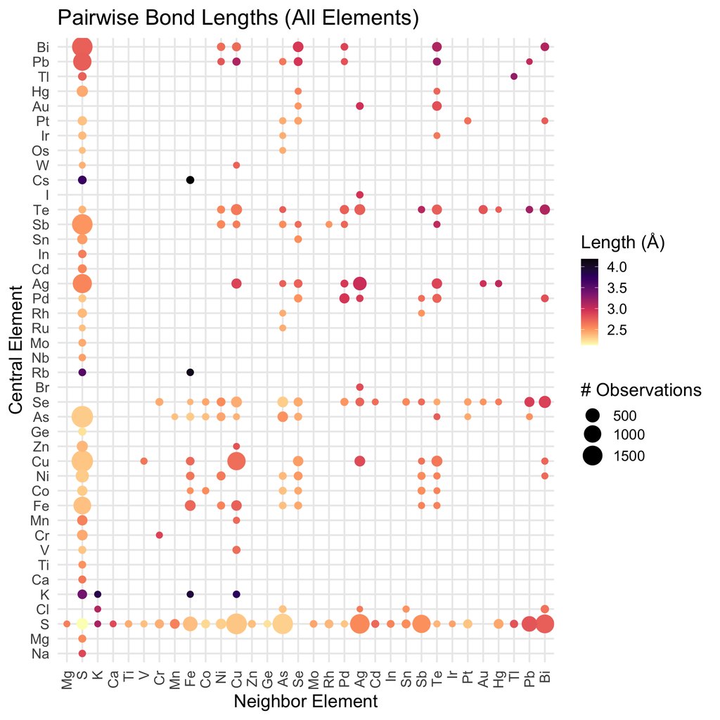

```r
pair_len_agg <- final_bonds_data[, .(MeanLength = mean(Distance), Count = .N), by = .(Element1, Z1, Element2, Z2)]
pair_len_agg <- pair_len_agg[Count >= 5]
pair_len_agg[, Element1 := fct_reorder(Element1, Z1)]
pair_len_agg[, Element2 := fct_reorder(Element2, Z2)]

p71 <- ggplot(pair_len_agg, aes(
  x = Element2,
  y = Element1,
  text = paste(
    "Center:",
    Element1,
    "<br>Neighbor:",
    Element2,
    "<br>Avg Dist:",
    round(MeanLength, 3),
    "Å",
    "<br>Count:",
    Count
  )
)) +
  geom_point(aes(size = Count, color = MeanLength)) +
  scale_color_viridis_c(option = "magma",
                        direction = -1,
                        name = "Length (Å)") +
  scale_size_continuous(
    range = c(2, 9),
    breaks = scales::breaks_pretty(n = 5),
    name = "# Observations"
  ) +
  labs(title = "Pairwise Bond Lengths (All Elements)", x = "Neighbor Element", y = "Central Element") +
  theme_minimal(base_size=18) +
  theme(axis.text = element_text(size = 14)) +
  theme(axis.text.x = element_text(
    angle = 90,
    vjust = 0.5,
    hjust = 1
  ))

# 1. Static output for export (Preserves legend)
print(p71)
```

```r
# 2. Interactive output for exploration (also exported to HTML)
plt71 <- ggplotly(p71, tooltip = "text")
saveWidget(plt71, file = file.path(export_dir_plotly, "7_1_pairwise_lengths.html"), selfcontained = TRUE)
plt71
```

[interactive chart not shown]

### 7.2 Pairwise Bond Angles

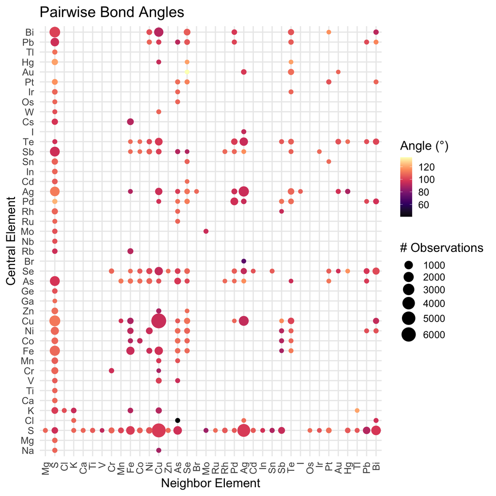

[interactive chart not shown]

```r
if (exists("all_angles_data") &&
    nrow(all_angles_data) > 0) {
  df_angles <- copy(all_angles_data)

  pair_ang_agg <- df_angles[, .(MeanAngle = mean(Angle), Count = .N), by = .(Element1, Z1, Element2, Z2)]
  pair_ang_agg <- pair_ang_agg[Count >= 5]
  pair_ang_agg[, Element1 := fct_reorder(Element1, Z1)]
  pair_ang_agg[, Element2 := fct_reorder(Element2, Z2)]

  p72 <- ggplot(pair_ang_agg, aes(
    x = Element2,
    y = Element1,
    text = paste(
      "Center:",
      Element1,
      "<br>Neighbor:",
      Element2,
      "<br>Avg Angle:",
      round(MeanAngle, 1),
      "°",
      "<br>Count:",
      Count
    )
  )) +
    geom_point(aes(size = Count, color = MeanAngle)) +
    scale_color_viridis_c(option = "magma", name = "Angle (°)") +
    scale_size_continuous(
      range = c(2, 9),
      breaks = scales::breaks_pretty(n = 5),
      name = "# Observations"
    ) +
    labs(title = "Pairwise Bond Angles", x = "Neighbor Element", y = "Central Element") +
    theme_minimal(base_size=18) +
  theme(axis.text = element_text(size = 14)) +
    theme(axis.text.x = element_text(
      angle = 90,
      vjust = 0.5,
      hjust = 1
    ))

  # 1. Static output for export (Preserves legend)
  print(p72)

  # 2. Interactive output for exploration (also exported to HTML)
  plt72 <- ggplotly(p72, tooltip = "text")
  saveWidget(plt72, file = file.path(export_dir_plotly, "7_2_pairwise_angles.html"), selfcontained = TRUE)
  plt72
} else {
  cat("No bond angle data available.\n")
}
```

## 8. Coordination Number Analysis

### 8.1 ECon Coordination Number

Continuous CN output directly by the ECon algorithm without additional occupancy weights.

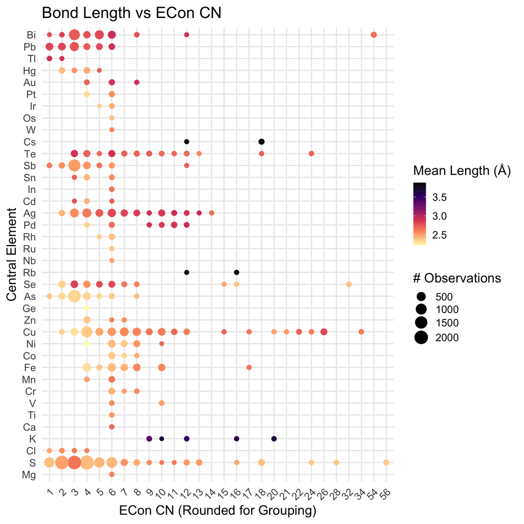

```r
reg_cn_agg <- final_bonds_data[, .(MeanLength = mean(Distance), Count = .N), by = .(Element1, Z1, CoordinationNumber)]
reg_cn_agg <- reg_cn_agg[Count >= 10]
reg_cn_agg[, Element1 := fct_reorder(Element1, Z1)]

p81 <- ggplot(reg_cn_agg, aes(
  x = factor(round(CoordinationNumber, 1)),
  y = Element1,
  text = paste(
    "Element:",
    Element1,
    "<br>ECon CN:",
    round(CoordinationNumber, 1),
    "<br>Avg Dist:",
    round(MeanLength, 3),
    "Å",
    "<br>Count:",
    Count
  )
)) +
  geom_point(aes(size = Count, color = MeanLength)) +
  scale_color_viridis_c(option = "magma",
                        direction = -1,
                        name = "Mean Length (Å)") +
  scale_size_continuous(
    range = c(2, 8),
    breaks = scales::breaks_pretty(n = 5),
    name = "# Observations"
  ) +
  labs(title = "Bond Length vs ECon CN", x = "ECon CN (Rounded for Grouping)", y = "Central Element") +
  theme_minimal(base_size=18) +
  theme(axis.text = element_text(size = 14)) +
  theme(axis.text.x = element_text(angle = 45, hjust = 1))

# 1. Static
print(p81)
```

```r
# 2. Interactive (also exported to HTML)
plt81 <- ggplotly(p81, tooltip = "text")
saveWidget(plt81, file = file.path(export_dir_plotly, "8_1_regular_cn.html"), selfcontained = TRUE)
plt81
```

[interactive chart not shown]

### 8.2 Weighted CN

This view re-analyzes the data by adjusting for crystallographic site occupancies. High Geometric environments often condense down into standard structural motifs.

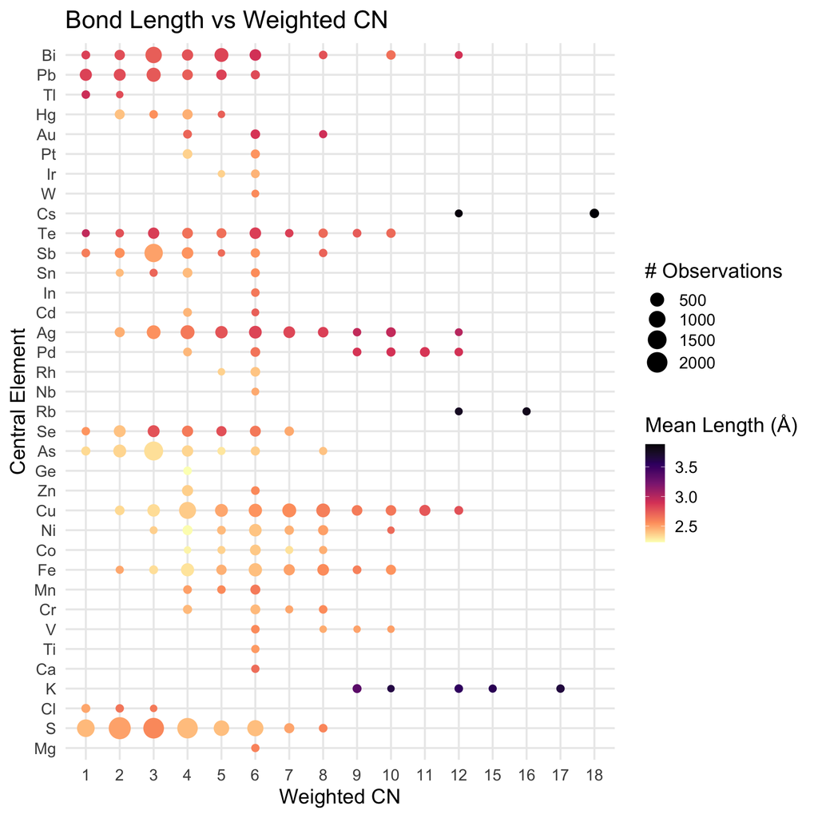

```r
wcn_agg <- final_bonds_data[, .(MeanLength = mean(Distance), Count = .N), by = .(Element1, Z1, RoundedWeightedCN)]
wcn_agg <- wcn_agg[Count >= 10 & RoundedWeightedCN > 0]
wcn_agg[, Element1 := fct_reorder(Element1, Z1)]

p82 <- ggplot(wcn_agg, aes(
  x = factor(RoundedWeightedCN),
  y = Element1,
  text = paste(
    "Element:",
    Element1,
    "<br>W-CN:",
    RoundedWeightedCN,
    "<br>Avg Dist:",
    round(MeanLength, 3),
    "Å",
    "<br>Count:",
    Count
  )
)) +
  geom_point(aes(size = Count, color = MeanLength)) +
  scale_color_viridis_c(option = "magma",
                        direction = -1,
                        name = "Mean Length (Å)") +
  scale_size_continuous(
    range = c(2, 8),
    breaks = scales::breaks_pretty(n = 5),
    name = "# Observations"
  ) +
  labs(title = "Bond Length vs Weighted CN", x = "Weighted CN", y = "Central Element") +
  theme_minimal(base_size=18) +
  theme(axis.text = element_text(size = 14))

# 1. Static
print(p82)
```

```r
# 2. Interactive (also exported to HTML)
plt82 <- ggplotly(p82, tooltip = "text")
saveWidget(plt82, file = file.path(export_dir_plotly, "8_2_weighted_cn_z.html"), selfcontained = TRUE)
plt82
```

[interactive chart not shown]

### 8.3 Weighted CN (Sorted by Global Bond Length)

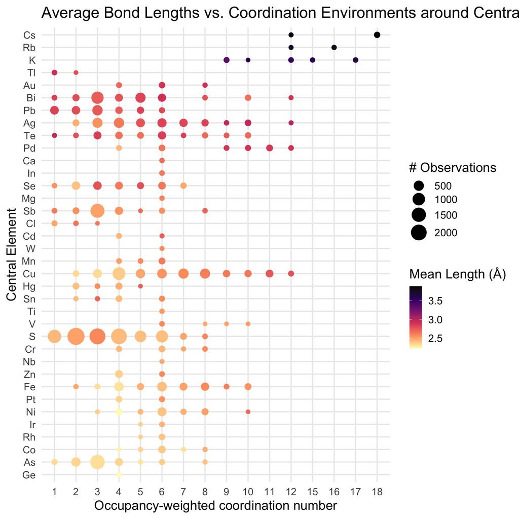

```r
wcn_agg_len <- copy(wcn_agg)
elem_means <- wcn_agg_len[, .(GlobalMean = mean(MeanLength)), by = Element1]
wcn_agg_len <- merge(wcn_agg_len, elem_means, by = "Element1")
wcn_agg_len[, Element1 := fct_reorder(Element1, GlobalMean)]

p83 <- ggplot(wcn_agg_len, aes(
  x = factor(RoundedWeightedCN),
  y = Element1,
  text = paste(
    "Element:",
    Element1,
    "<br>W-CN:",
    RoundedWeightedCN,
    "<br>Avg Dist:",
    round(MeanLength, 3),
    "Å"
  )
)) +
  geom_point(aes(size = Count, color = MeanLength)) +
  scale_color_viridis_c(option = "magma",
                        direction = -1,
                        name = "Mean Length (Å)") +
  scale_size_continuous(
    range = c(2, 10),
    breaks = scales::breaks_pretty(n = 5),
    name = "# Observations"
  ) +
  labs(title = "Average Bond Lengths vs. Coordination Environments around Central Atoms", x = "Occupancy-weighted coordination number", y = "Central Element") +
  theme_minimal(base_size=18) +
  theme(axis.text = element_text(size = 14))

# 1. Static
print(p83)
```

```r
# 2. Interactive (also exported to HTML)
plt83 <- ggplotly(p83, tooltip = "text")
saveWidget(plt83, file = file.path(export_dir_plotly, "8_3_weighted_cn_len.html"), selfcontained = TRUE)
plt83
```

[interactive chart not shown]

## 9. Chalcogen-Specific Analysis

Filtering the entire dataset to place the Chalcogens (Sulfur, Selenium, Tellurium) exclusively at the center of the geometric queries. In this section, we review Raw Bond Lengths, Normalized Bond Lengths, ECon Coordination Numbers, Weighted CNs, and Bond Angles.

```r
targets <- c("S", "Se", "Te")
df_center_chalc <- final_bonds_data[Element1 %in% targets]
```

### 9.1 S, Se, Te: Bond Lengths

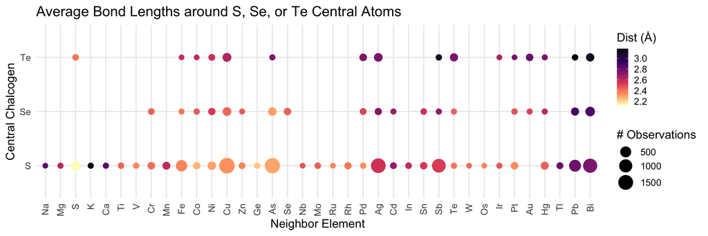

```r
agg_center <- df_center_chalc[, .(MeanDist = mean(Distance), N = .N), by =
                                .(Element1, Z1, Element2, Z2)]
agg_center <- agg_center[N >= 3]
agg_center[, Element1 := fct_reorder(Element1, Z1)]
agg_center[, Element2 := fct_reorder(Element2, Z2)]

p91 <- ggplot(agg_center, aes(
  x = Element2,
  y = Element1,
  text = paste(
    "Center:",
    Element1,
    "<br>Neighbor:",
    Element2,
    "<br>Dist:",
    round(MeanDist, 3),
    "Å",
    "<br>Obs:",
    N
  )
)) +
  geom_point(aes(size = N, color = MeanDist)) +
  scale_color_viridis_c(option = "magma",
                        direction = -1,
                        name = "Dist (Å)") +
  scale_size_continuous(
    range = c(3, 10),
    breaks = scales::breaks_pretty(n = 5),
    name = "# Observations"
  ) +
  labs(title = "Average Bond Lengths around S, Se, or Te Central Atoms", x = "Neighbor Element", y = "Central Chalcogen") +
  theme_minimal(base_size=18) +
  theme(axis.text = element_text(size = 14)) +
  theme(axis.text.x = element_text(
    angle = 90,
    vjust = 0.5,
    hjust = 1
  ))

# 1. Static
print(p91)
```

```r
# 2. Interactive (also exported to HTML)
plt91 <- ggplotly(p91, tooltip = "text")
saveWidget(plt91, file = file.path(export_dir_plotly, "9_1_chalc_center_len.html"), selfcontained = TRUE)
plt91
```

[interactive chart not shown]

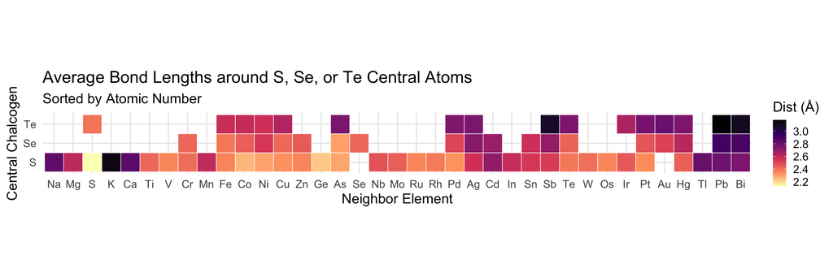

```r
# 3. Heatmap
ggplot(agg_center, aes(x = Element2, y = Element1, fill = MeanDist)) +
  geom_tile(color = "white") +
  scale_fill_viridis_c(option = "magma",
                       direction = -1,
                       name = "Dist (Å)") +
  labs(
    title = "Average Bond Lengths around S, Se, or Te Central Atoms",
    subtitle = "Sorted by Atomic Number",
    x = "Neighbor Element",
    y = "Central Chalcogen"
  ) +
  theme_minimal(base_size=18) +
  theme(axis.text = element_text(size = 14)) +
  coord_fixed()
```

### 9.2 S, Se, Te: Normalized Bond Lengths (Distance / Sum of Radii)

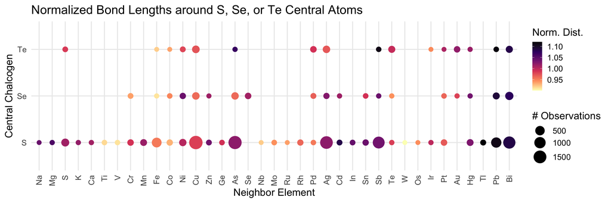

```r
agg_center_norm <- df_center_chalc[!is.na(NormalizedDistance), .(MeanNormDist = mean(NormalizedDistance), N =
                                                                   .N), by = .(Element1, Z1, Element2, Z2)]
agg_center_norm <- agg_center_norm[N >= 3]
agg_center_norm[, Element1 := fct_reorder(Element1, Z1)]
agg_center_norm[, Element2 := fct_reorder(Element2, Z2)]

p92 <- ggplot(agg_center_norm, aes(
  x = Element2,
  y = Element1,
  text = paste(
    "Center:",
    Element1,
    "<br>Neighbor:",
    Element2,
    "<br>Norm Dist:",
    round(MeanNormDist, 3),
    "<br>Obs:",
    N
  )
)) +
  geom_point(aes(size = N, color = MeanNormDist)) +
  scale_color_viridis_c(option = "magma",
                        direction = -1,
                        name = "Norm. Dist.") +
  scale_size_continuous(
    range = c(3, 10),
    breaks = scales::breaks_pretty(n = 5),
    name = "# Observations"
  ) +
  labs(title = "Normalized Bond Lengths around S, Se, or Te Central Atoms", x = "Neighbor Element", y = "Central Chalcogen") +
  theme_minimal(base_size=18) +
  theme(axis.text = element_text(size = 14)) +
  theme(axis.text.x = element_text(
    angle = 90,
    vjust = 0.5,
    hjust = 1
  ))

# 1. Static
print(p92)
```

```r
# 2. Interactive (also exported to HTML)
plt92 <- ggplotly(p92, tooltip = "text")
saveWidget(plt92, file = file.path(export_dir_plotly, "9_2_chalc_center_norm_len.html"), selfcontained = TRUE)
plt92
```

[interactive chart not shown]

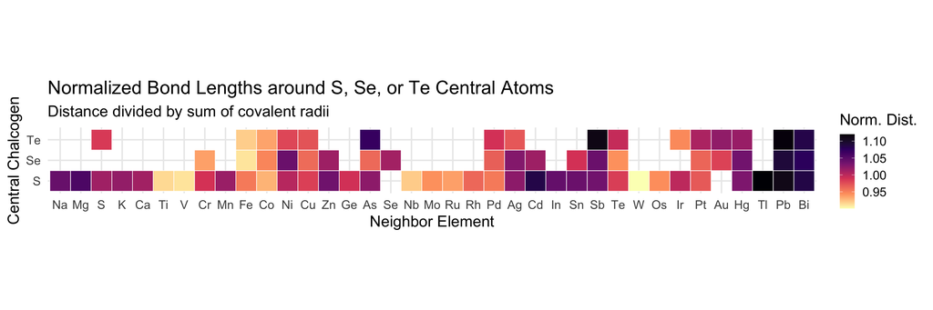

```r
# 3. Heatmap
ggplot(agg_center_norm,
       aes(x = Element2, y = Element1, fill = MeanNormDist)) +
  geom_tile(color = "white") +
  scale_fill_viridis_c(option = "magma",
                       direction = -1,
                       name = "Norm. Dist.") +
  labs(
    title = "Normalized Bond Lengths around S, Se, or Te Central Atoms",
    subtitle = "Distance divided by sum of covalent radii",
    x = "Neighbor Element",
    y = "Central Chalcogen"
  ) +
  theme_minimal(base_size=18) +
  theme(axis.text = element_text(size = 14)) +
  coord_fixed()
```

### 9.3 S, Se, Te: ECon Coordination Number

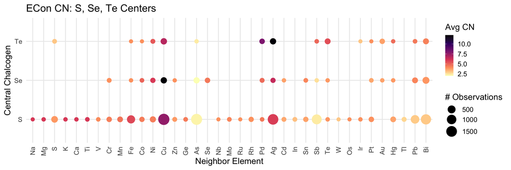

```r
agg_center_cn <- df_center_chalc[, .(MeanCN = mean(CoordinationNumber), N =
                                       .N), by = .(Element1, Z1, Element2, Z2)]
agg_center_cn <- agg_center_cn[N >= 3]
agg_center_cn[, Element1 := fct_reorder(Element1, Z1)]
agg_center_cn[, Element2 := fct_reorder(Element2, Z2)]

p93 <- ggplot(agg_center_cn, aes(
  x = Element2,
  y = Element1,
  text = paste(
    "Center:",
    Element1,
    "<br>Neighbor:",
    Element2,
    "<br>Avg ECon CN:",
    round(MeanCN, 2),
    "<br>Obs:",
    N
  )
)) +
  geom_point(aes(size = N, color = MeanCN)) +
  scale_color_viridis_c(option = "magma",
                        direction = -1,
                        name = "Avg CN") +
  scale_size_continuous(
    range = c(3, 10),
    breaks = scales::breaks_pretty(n = 5),
    name = "# Observations"
  ) +
  labs(title = "ECon CN: S, Se, Te Centers", x = "Neighbor Element", y = "Central Chalcogen") +
  theme_minimal(base_size=18) +
  theme(axis.text = element_text(size = 14)) +
  theme(axis.text.x = element_text(
    angle = 90,
    vjust = 0.5,
    hjust = 1
  ))

# 1. Static
print(p93)
```

```r
# 2. Interactive (also exported to HTML)
plt93 <- ggplotly(p93, tooltip = "text")
saveWidget(plt93, file = file.path(export_dir_plotly, "9_3_chalc_center_cn.html"), selfcontained = TRUE)
plt93
```

[interactive chart not shown]

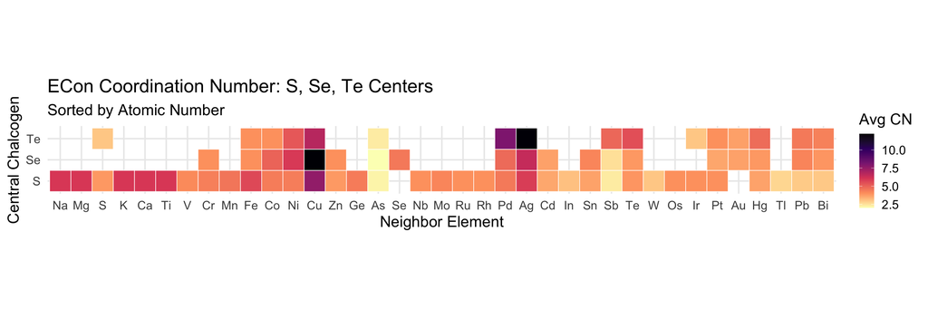

```r
# 3. Heatmap
ggplot(agg_center_cn, aes(x = Element2, y = Element1, fill = MeanCN)) +
  geom_tile(color = "white") +
  scale_fill_viridis_c(option = "magma",
                       direction = -1,
                       name = "Avg CN") +
  labs(
    title = "ECon Coordination Number: S, Se, Te Centers",
    subtitle = "Sorted by Atomic Number",
    x = "Neighbor Element",
    y = "Central Chalcogen"
  ) +
  theme_minimal(base_size=18) +
  theme(axis.text = element_text(size = 14)) +
  coord_fixed()
```

### 9.4 S, Se, Te: Weighted CN (Special Aggregation)

In this visualization, we map **Specific WCN** (the fraction of the coordination environment contributed exclusively by the specific element pairing) and **Total WCN** (the complete occupancy-corrected size of the environment). * **Color:** The average specific element-element Weighted CN. * **Size:** The average Total Weighted CN for the site.

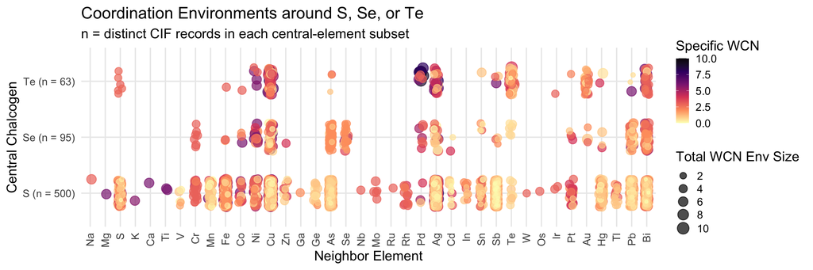

```r
# 1. Extract the actual Total WCN per central site
atom_totals <- final_bonds_data[, .(Total_WCN = first(CN_Weighted)), by = .(file_name, Atom1, Element1, Z1)]

# 2. Extract Exact Specific WCN (Summing the true occupancies of the bonded neighbors)
atom_specifics <- final_bonds_data[, .(Specific_WCN = sum(Occupancy)), by = .(file_name, Atom1, Element1, Z1, Element2, Z2)]

# 3. Merge Specific WCN with Total WCN for plotting
df_plot_wcn <- merge(atom_specifics,
                     atom_totals,
                     by = c("file_name", "Atom1", "Element1", "Z1"))

# 4. Filter down to only Chalcogen centers
targets <- c("S", "Se", "Te")
df_plot_chalc <- df_plot_wcn[Element1 %in% targets]

subset_counts <- df_plot_chalc[, .(N = uniqueN(file_name)), by = Element1]
fwrite(subset_counts, file.path(params$output_dir, "figure5_subset_counts.csv"))
count_labels <- setNames(paste0(subset_counts$Element1, " (n = ", subset_counts$N, ")"), subset_counts$Element1)

# Reorder factors by Atomic Number for the plot axes
df_plot_chalc[, Element1 := fct_reorder(Element1, Z1)]
df_plot_chalc[, Element2 := fct_reorder(Element2, Z2)]

# Sort data so LARGEST bubbles are plotted FIRST (background),
# and SMALLEST bubbles are plotted LAST (foreground)
df_plot_chalc <- df_plot_chalc[order(-Total_WCN)]

# Extract maximums to anchor the legends properly
max_tot <- ceiling(max(df_plot_chalc$Total_WCN, na.rm = TRUE))
max_spec <- ceiling(max(df_plot_chalc$Specific_WCN, na.rm = TRUE))

p94 <- ggplot(df_plot_chalc, aes(
  x = Element2,
  y = Element1,
  text = paste(
    "File:",
    file_name,
    "<br>Center:",
    Element1,
    "(Site:",
    Atom1,
    ")",
    "<br>Neighbor:",
    Element2,
    "<br>Specific WCN (Color):",
    round(Specific_WCN, 2),
    "<br>Total Env Size (Size):",
    round(Total_WCN, 2)
  )
)) +
  scale_y_discrete(labels = count_labels) +
  # Apply vertical jitter (offset)
  geom_jitter(
    aes(size = Total_WCN, color = Specific_WCN),
    alpha = 0.7, position = position_jitter(width = 0.15, height = 0.25, seed = 123)
  ) +
  scale_color_viridis_c(
    option = "magma",
    direction = -1,
    name = "Specific WCN",
    limits = c(0, max_spec)
  ) +
  scale_size_continuous(
    range = c(1, 7),
    name = "Total WCN Env Size",
    breaks = seq(2, max_tot, by = 2),
    limits = c(0, max_tot)
  ) +
  labs(
    title = "Coordination Environments around S, Se, or Te",
    subtitle = "n = distinct CIF records in each central-element subset",
    x = "Neighbor Element",
    y = "Central Chalcogen"
  ) +
  theme_minimal(base_size=18) +
  theme(axis.text = element_text(size = 14)) +
  theme(axis.text.x = element_text(
    angle = 90,
    vjust = 0.5,
    hjust = 1
  ))

# 1. Static
print(p94)
```

```r
# 2. Interactive (also exported to HTML)
plt94 <- ggplotly(p94, tooltip = "text")
saveWidget(plt94, file = file.path(export_dir_plotly, "9_4_chalc_center_wcn.html"), selfcontained = TRUE)
plt94
```

[interactive chart not shown]

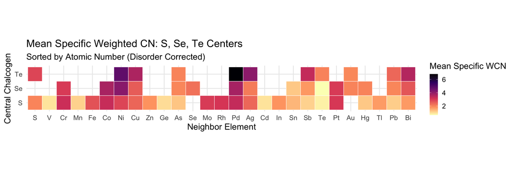

```r
# 3. Aggregate Heatmap
agg_center_wcn <- df_plot_chalc[, .(MeanSpecificWCN = mean(Specific_WCN), N =
                                      .N), by = .(Element1, Z1, Element2, Z2)]
agg_center_wcn <- agg_center_wcn[N >= 3]

ggplot(agg_center_wcn,
       aes(x = Element2, y = Element1, fill = MeanSpecificWCN)) +
  geom_tile(color = "white") +
  scale_fill_viridis_c(option = "magma",
                       direction = -1,
                       name = "Mean Specific WCN") +
  labs(
    title = "Mean Specific Weighted CN: S, Se, Te Centers",
    subtitle = "Sorted by Atomic Number (Disorder Corrected)",
    x = "Neighbor Element",
    y = "Central Chalcogen"
  ) +
  theme_minimal(base_size=18) +
  theme(axis.text = element_text(size = 14)) +
  coord_fixed()
```

To eliminate the vertical overlap here is a split analysis, with the above chart separated into three distinct plots for **Sulfur**, **Selenium**, and **Tellurium**.

### 9.4.1 Specific WCN: Sulfur (S) Centers

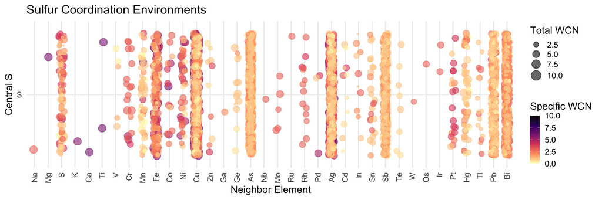

```r
# Filter for S only
df_s <- df_plot_chalc[Element1 == "S"]

p_s <- ggplot(df_s, aes(
  x = Element2,
  y = Element1,
  text = paste(
    "File:",
    file_name,
    "<br>Site:",
    Atom1,
    "<br>Neighbor:",
    Element2,
    "<br>Specific WCN:",
    round(Specific_WCN, 2),
    "<br>Total Site WCN:",
    round(Total_WCN, 2)
  )
)) +
  geom_jitter(
    aes(size = Total_WCN, color = Specific_WCN),
    width = 0.2,
    height = 0.5,
    alpha = 0.6
  ) +
  scale_color_viridis_c(
    option = "magma",
    direction = -1,
    name = "Specific WCN",
    limits = c(0, max_spec)
  ) +
  scale_size_continuous(range = c(1, 8),
                        name = "Total WCN",
                        limits = c(1, max_tot)) +
  labs(title = "Sulfur Coordination Environments", x = "Neighbor Element", y = "Central S") +
  theme_minimal(base_size=18) +
  theme(axis.text = element_text(size = 14)) +
  theme(axis.text.x = element_text(
    angle = 90,
    vjust = 0.5,
    hjust = 1
  ))

print(p_s)
```

```r
plt_s_int <- ggplotly(p_s, tooltip = "text")
saveWidget(plt_s_int, file = file.path(export_dir_plotly, "9_4_1_chalc_wcn_s.html"), selfcontained = TRUE)
plt_s_int
```

[interactive chart not shown]

### 9.4.2 Specific WCN: Selenium (Se) Centers

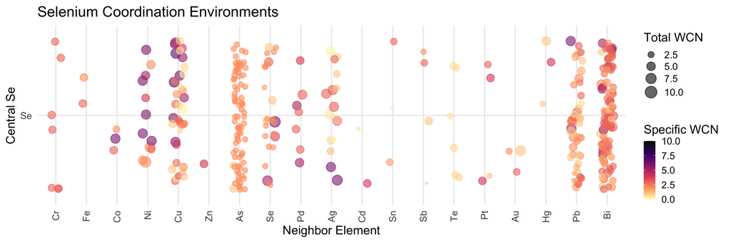

```r
# Filter for Se only
df_se <- df_plot_chalc[Element1 == "Se"]

p_se <- ggplot(df_se, aes(
  x = Element2,
  y = Element1,
  text = paste(
    "File:",
    file_name,
    "<br>Site:",
    Atom1,
    "<br>Neighbor:",
    Element2,
    "<br>Specific WCN:",
    round(Specific_WCN, 2),
    "<br>Total Site WCN:",
    round(Total_WCN, 2)
  )
)) +
  geom_jitter(
    aes(size = Total_WCN, color = Specific_WCN),
    width = 0.2,
    height = 0.5,
    alpha = 0.6
  ) +
  scale_color_viridis_c(
    option = "magma",
    direction = -1,
    name = "Specific WCN",
    limits = c(0, max_spec)
  ) +
  scale_size_continuous(range = c(1, 8),
                        name = "Total WCN",
                        limits = c(1, max_tot)) +
  labs(title = "Selenium Coordination Environments", x = "Neighbor Element", y = "Central Se") +
  theme_minimal(base_size=18) +
  theme(axis.text = element_text(size = 14)) +
  theme(axis.text.x = element_text(
    angle = 90,
    vjust = 0.5,
    hjust = 1
  ))

print(p_se)
```

```r
plt_se_int <- ggplotly(p_se, tooltip = "text")
saveWidget(plt_se_int, file = file.path(export_dir_plotly, "9_4_2_chalc_wcn_se.html"), selfcontained = TRUE)
plt_se_int
```

[interactive chart not shown]

### 9.4.3 Specific WCN: Tellurium (Te) Centers

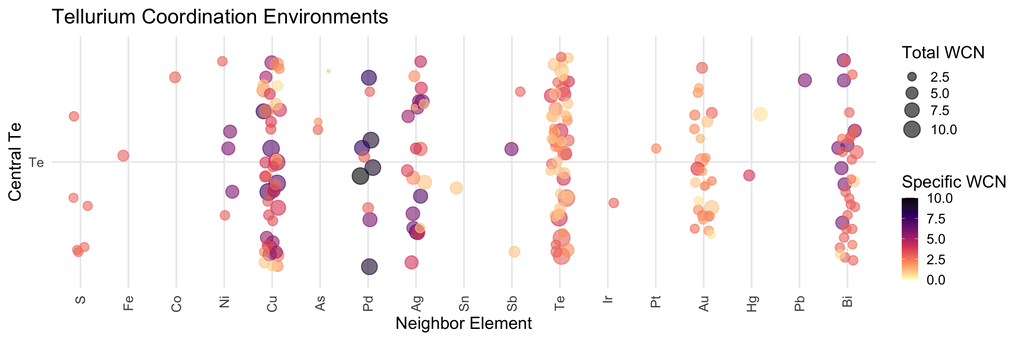

```r
# Filter for Te only
df_te <- df_plot_chalc[Element1 == "Te"]

p_te <- ggplot(df_te, aes(
  x = Element2,
  y = Element1,
  text = paste(
    "File:",
    file_name,
    "<br>Site:",
    Atom1,
    "<br>Neighbor:",
    Element2,
    "<br>Specific WCN:",
    round(Specific_WCN, 2),
    "<br>Total Site WCN:",
    round(Total_WCN, 2)
  )
)) +
  geom_jitter(
    aes(size = Total_WCN, color = Specific_WCN),
    width = 0.2,
    height = 0.5,
    alpha = 0.6
  ) +
  scale_color_viridis_c(
    option = "magma",
    direction = -1,
    name = "Specific WCN",
    limits = c(0, max_spec)
  ) +
  scale_size_continuous(range = c(1, 8),
                        name = "Total WCN",
                        limits = c(1, max_tot)) +
  labs(title = "Tellurium Coordination Environments", x = "Neighbor Element", y = "Central Te") +
  theme_minimal(base_size=18) +
  theme(axis.text = element_text(size = 14)) +
  theme(axis.text.x = element_text(
    angle = 90,
    vjust = 0.5,
    hjust = 1
  ))

print(p_te)
```

```r
plt_te_int <- ggplotly(p_te, tooltip = "text")
saveWidget(plt_te_int, file = file.path(export_dir_plotly, "9_4_3_chalc_wcn_te.html"), selfcontained = TRUE)
plt_te_int
```

[interactive chart not shown]

### 9.5 S, Se, Te: Bond Angles

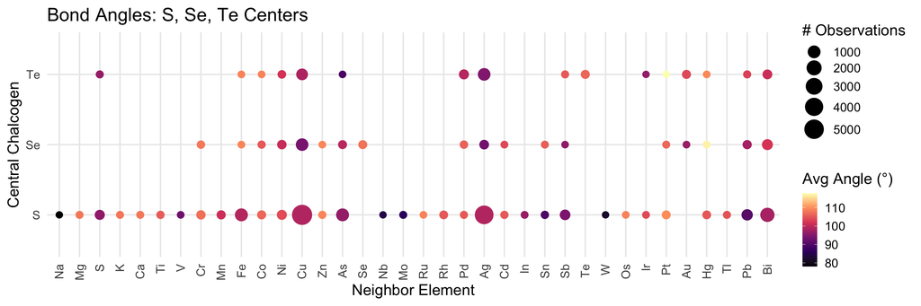

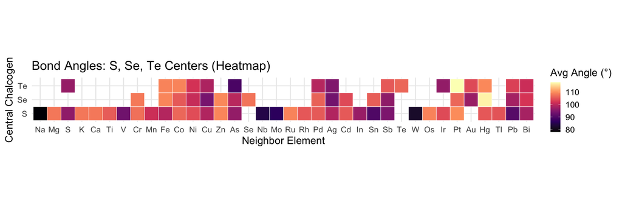

```r
if (exists("all_angles_data") &&
    nrow(all_angles_data) > 0) {
  df_angles_sub <- all_angles_data[Element1 %in% targets]

  agg_angles_chalc <- df_angles_sub[, .(MeanAngle = mean(Angle), N = .N), by =
                                      .(Element1, Z1, Element2, Z2)]
  agg_angles_chalc <- agg_angles_chalc[N >= 3]
  agg_angles_chalc[, Element1 := fct_reorder(Element1, Z1)]
  agg_angles_chalc[, Element2 := fct_reorder(Element2, Z2)]

  p95 <- ggplot(agg_angles_chalc, aes(
    x = Element2,
    y = Element1,
    text = paste(
      "Center:",
      Element1,
      "<br>Neighbor:",
      Element2,
      "<br>Avg Angle:",
      round(MeanAngle, 1),
      "°",
      "<br>Obs:",
      N
    )
  )) +
    geom_point(aes(size = N, color = MeanAngle)) +
    scale_color_viridis_c(option = "magma", name = "Avg Angle (°)") +
    scale_size_continuous(
      range = c(3, 10),
      breaks = scales::breaks_pretty(n = 5),
      name = "# Observations"
    ) +
    labs(title = "Bond Angles: S, Se, Te Centers", x = "Neighbor Element", y = "Central Chalcogen") +
    theme_minimal(base_size=18) +
  theme(axis.text = element_text(size = 14)) +
    theme(axis.text.x = element_text(
      angle = 90,
      vjust = 0.5,
      hjust = 1
    ))

  # 1. Static
  print(p95)

  # 2. Interactive (also exported to HTML)
  plt95 <- ggplotly(p95, tooltip = "text")
  saveWidget(plt95, file = file.path(export_dir_plotly, "9_5_chalc_center_angles.html"), selfcontained = TRUE)
  plt95

  # 3. Heatmap
  ggplot(agg_angles_chalc,
         aes(x = Element2, y = Element1, fill = MeanAngle)) +
    geom_tile(color = "white") +
    scale_fill_viridis_c(option = "magma", name = "Avg Angle (°)") +
    labs(title = "Bond Angles: S, Se, Te Centers (Heatmap)", x = "Neighbor Element", y = "Central Chalcogen") +
    theme_minimal(base_size=18) +
  theme(axis.text = element_text(size = 14)) +
    coord_fixed()
} else {
  cat("No angle data available.\n")
}
```

## 10. Distribution Analysis

This visualization compares the distribution of bond lengths for the most common coordination numbers (e.g., 4 and 6), allowing us to see the “spread” of bond distances for specific elements. Because ECon generates continuous decimal values, we round them to the nearest integer solely for visualization grouping.

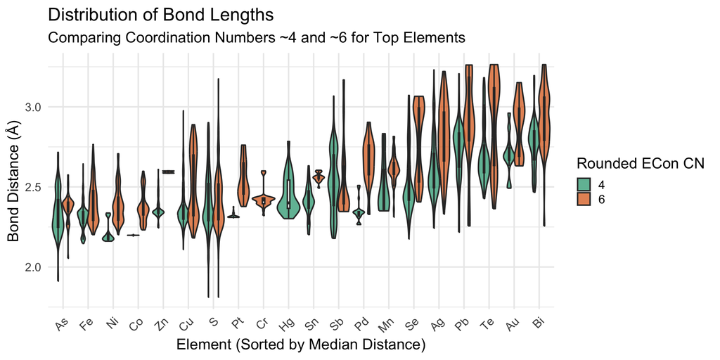

```r
# --- Distribution Analysis (Violin Plot) ---

# 1. Round continuous ECon CNs and filter for common Coordination Numbers
violin_data <- copy(final_bonds_data)
violin_data[, RoundedCN := round(CoordinationNumber)]
common_cns <- c(4, 6) # Focusing on Tetrahedral and Octahedral equivalent environments
violin_data <- violin_data[RoundedCN %in% common_cns]

# 2. Filter to top 20 most frequent elements to keep the x-axis clean
top_elements <- violin_data[, .N, by = Element1][order(-N)][1:20, Element1]
violin_data <- violin_data[Element1 %in% top_elements]

# 3. Plot
ggplot(violin_data, aes(x = reorder(Element1, Distance), y = Distance)) +
  geom_violin(
    aes(fill = factor(RoundedCN)),
    scale = "width",
    alpha = 0.7,
    position = position_dodge(width = 0.8)
  ) +
  geom_boxplot(
    aes(group = interaction(Element1, RoundedCN)),
    width = 0.1,
    outlier.shape = NA,
    fill = "white",
    position = position_dodge(width = 0.8)
  ) +
  scale_fill_brewer(palette = "Dark2", name = "Rounded ECon CN") +
  labs(
    title = "Distribution of Bond Lengths",
    subtitle = "Comparing Coordination Numbers ~4 and ~6 for Top Elements",
    x = "Element (Sorted by Median Distance)",
    y = "Bond Distance (Å)"
  ) +
  theme_minimal(base_size=18) +
  theme(axis.text = element_text(size = 14)) +
  theme(axis.text.x = element_text(angle = 45, hjust = 1))
```

## 11. Advanced: Length vs Angle (Grouped by Neighbor Family)

Faceted by S, Se, Te. Neighbors are colored by **standard IUPAC periodic table groups** (Alkali metals, Reactive nonmetals, Lanthanides, etc.), while preserving the split between **Early TMs** and **Late TMs**.

*(Note: Data extraction steps below use `copy()` extensively to guarantee safety and isolation from the global objects, preventing any interactive environment bleeding).*

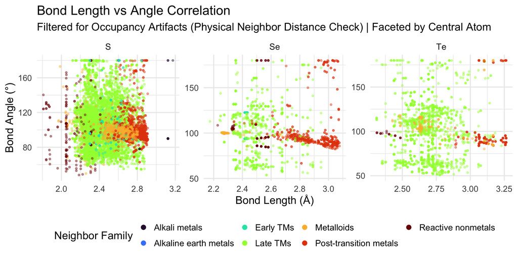

[interactive chart not shown]

```r
# --- 1. Expanded Group Metadata ---

extended_groups <- data.table(
  Symbol = c(
    # Alkali metals
    "Li", "Na", "K", "Rb", "Cs", "Fr",

    # Alkaline earth metals
    "Be", "Mg", "Ca", "Sr", "Ba", "Ra",

    # Early TMs (Now includes up to Group 7: Mn, Tc, Re)
    "Sc", "Y", "Ti", "Zr", "Hf", "V", "Nb", "Ta", "Cr", "Mo", "W", "Mn", "Tc", "Re",

    # Late TMs (Groups 8-12)
    "Fe", "Ru", "Os", "Co", "Rh", "Ir", "Ni", "Pd", "Pt", "Cu", "Ag", "Au", "Zn", "Cd", "Hg",

    # Post-transition metals
    "Al", "Ga", "In", "Tl", "Sn", "Pb", "Bi", "Po",

    # Metalloids
    "B", "Si", "Ge", "As", "Sb", "Te", "At",

    # Reactive nonmetals
    "H", "C", "N", "P", "O", "S", "Se", "F", "Cl", "Br", "I",

    # Noble gases
    "He", "Ne", "Ar", "Kr", "Xe", "Rn",

    # Lanthanides
    "La", "Ce", "Pr", "Nd", "Pm", "Sm", "Eu", "Gd", "Tb", "Dy", "Ho", "Er", "Tm", "Yb", "Lu",

    # Actinides
    "Ac", "Th", "Pa", "U", "Np", "Pu", "Am", "Cm", "Bk", "Cf", "Es", "Fm", "Md", "No", "Lr",

    # Unknown properties
    "Rf", "Db", "Sg", "Bh", "Hs", "Mt", "Ds", "Rg", "Cn", "Nh", "Fl", "Mc", "Lv", "Ts", "Og"
  ),
  GroupLabel = c(
    rep("Alkali metals", 6),
    rep("Alkaline earth metals", 6),
    rep("Early TMs", 14),
    rep("Late TMs", 15),
    rep("Post-transition metals", 8),
    rep("Metalloids", 7),
    rep("Reactive nonmetals", 11),
    rep("Noble gases", 6),
    rep("Lanthanides", 15),
    rep("Actinides", 15),
    rep("Unknown properties", 15)
  )
)

if (exists("all_angles_data") && nrow(all_angles_data) > 0) {
  # A. Filter Angles for S, Se, Te centers ONLY
  target_centers <- c("S", "Se", "Te")
  df_angles_sub <- copy(all_angles_data[CentralAtom %like% "^(S|Se|Te)([0-9]|$|_)"])

  # Extract Base Symbols
  df_angles_sub[, CenterSym := str_extract(CentralAtom, "^[A-Za-z]+")]
  df_angles_sub[, NeighborSym1 := str_extract(Neighbor1, "^[A-Za-z]+")]
  df_angles_sub[, NeighborSym2 := str_extract(Neighbor2, "^[A-Za-z]+")]

  # explicitly filter to keep only S, Se, Te
  df_angles_sub <- df_angles_sub[CenterSym %in% target_centers]

  # B. Prepare Raw ECon Bonds List for Distance Fetching
  # We use final_bonds_data, which contains the raw lengths of all ECon bonds.
  # This merge does NOT filter the angles, it merely acts as a lookup table to get lengths.
  raw_econ_bonds <- copy(unique(final_bonds_data[, .(file_name, Atom1, Atom2, Distance)], by = c("file_name", "Atom1", "Atom2")))

  # C. Fetch Dist1 (Central to Neighbor1)
  plot_data <- merge(
    df_angles_sub,
    raw_econ_bonds,
    by.x = c("file_name", "CentralAtom", "Neighbor1"),
    by.y = c("file_name", "Atom1", "Atom2"),
    allow.cartesian = TRUE
  )
  setnames(plot_data, "Distance", "Dist1")

  # D. Fetch Dist2 (Central to Neighbor2)
  plot_data <- merge(
    plot_data,
    raw_econ_bonds,
    by.x = c("file_name", "CentralAtom", "Neighbor2"),
    by.y = c("file_name", "Atom1", "Atom2")
  )
  setnames(plot_data, "Distance", "Dist2")

  # E. Calculate Raw Distance between Neighbor1 and Neighbor2 (Law of Cosines)
  plot_data[, Angle_rad := Angle * pi / 180]
  plot_data[, Dist_N1_N2 := sqrt(Dist1^2 + Dist2^2 - 2 * Dist1 * Dist2 * cos(Angle_rad))]

  # F. Merge Covalent Radii to determine the physical threshold
  # Merge for Neighbor1
  plot_data <- merge(
    plot_data,
    custom_radii_values[, .(Symbol, Radius)],
    by.x = "NeighborSym1",
    by.y = "Symbol",
    all.x = TRUE
  )
  setnames(plot_data, "Radius", "Radius_N1")

  # Merge for Neighbor2
  plot_data <- merge(
    plot_data,
    custom_radii_values[, .(Symbol, Radius)],
    by.x = "NeighborSym2",
    by.y = "Symbol",
    all.x = TRUE
  )
  setnames(plot_data, "Radius", "Radius_N2")

  # G. Apply Physical Distance Check (The 15% Ghost Filter)
  # Removes pairs where the distance between the two neighbors is less than the
  # sum of their covalent radii multiplied by (1 - 0.15)
  plot_data <- plot_data[!is.na(Radius_N1) & !is.na(Radius_N2)]
  plot_data[, expected_dist := Radius_N1 + Radius_N2]
  plot_data[, lower_bound := expected_dist * (1 - 0.15)]
  plot_data <- plot_data[Dist_N1_N2 >= lower_bound]

  # H. Merge Neighbor Group Info (Categorized by Neighbor 1)
  plot_data <- merge(
    plot_data,
    extended_groups,
    by.x = "NeighborSym1",
    by.y = "Symbol",
    all.x = TRUE
  )

  # Remove NAs (elements not in our group list)
  plot_data <- plot_data[!is.na(GroupLabel)]

  # I. Sort Central Atom for Plotting Order
  plot_data[, CenterSym := factor(CenterSym, levels = c("S", "Se", "Te"))]

  # --- 3. Plotting ---
  p11 <- ggplot(plot_data, aes(
    x = Dist1,
    y = Angle,
    text = paste(
      "File:",
      file_name,
      "Center:",
      CentralAtom,
      "<br>Neighbor1:",
      Neighbor1,
      "<br>Neighbor2:",
      Neighbor2,
      "<br>Group:",
      GroupLabel,
      "<br>N1-N2 Dist:",
      round(Dist_N1_N2, 3),
      "Å",
      "<br>Allowed Minimum:",
      round(lower_bound, 3),
      "Å",
      "<br>Angle:",
      Angle,
      "°"
    )
  )) +
    geom_point(aes(color = GroupLabel), alpha = 0.4, size = 1) +
    facet_wrap( ~ CenterSym, scales = "free", ncol = 3) +
    scale_color_viridis_d(option = "turbo", name = "Neighbor Family") +
    labs(
      title = "Bond Length vs Angle Correlation",
      subtitle = "Filtered for Occupancy Artifacts (Physical Neighbor Distance Check) | Faceted by Central Atom",
      x = "Bond Length (Å)",
      y = "Bond Angle (°)"
    ) +
    theme_minimal(base_size=18) +
  theme(axis.text = element_text(size = 14)) +
    theme(legend.position = "bottom") +
    guides(color = guide_legend(override.aes = list(alpha = 1, size = 3)))

  # 1. Static
  print(p11)

  # 2. Interactive (also exported to HTML)
  plt11 <- toWebGL(ggplotly(p11, tooltip = "text")) %>%
    layout(legend = list(
      orientation = "h",
      x = 0,
      y = -0.2
    ))
  saveWidget(plt11, file = file.path(export_dir_plotly, "11_advanced_scatter.html"), selfcontained = TRUE)
  plt11

} else {
  cat("No angle data available to plot.\n")
}
```

## 12. Multi-Algorithm Analysis on Chalcogenide Subset

This section samples ~50 chalcogenide CIF files from our previously filtered list and runs them through a multi-algorithm coordination analysis. While the entire notebook was rebuilt around **ECon**, here we benchmark it directly alongside the other main bonding algorithms provided by `crystract`. We extract both geometric/standard CNs and Weighted CNs.

```r
# --- 1. Load required libraries ---
library(crystract)
library(data.table)

set_radii_data(custom_radii_values)

# --- 2. Sample ~50 Chalcogenide Files ---
# Set seed for reproducibility
set.seed(123)

# Destination for the test files
dest_dir <- tempfile("algorithm-comparison-", tmpdir = params$output_dir)
if (!dir.exists(dest_dir)) {
  dir.create(dest_dir, recursive = TRUE)
}

# Use `target_files` (generated in Section 3) to guarantee chemistry logic
num_to_sample <- min(50, length(target_files))
selected_files <- sample(target_files, num_to_sample)

# Copy selected files to destination folder explicitly
dest_files <- file.path(dest_dir, basename(selected_files))
file.copy(from = selected_files,
          to = dest_files,
          overwrite = TRUE)

# --- 3. Run the batch analysis ---
cat("\nStarting multi-algorithm batch analysis on CIF files...\n")
results <- analyze_cif_files(
  file_paths = dest_dir,
  tolerance = 1e-4,
  bonding_algorithms = c("minimum_distance", "brunner", "econ", "voronoi", "crystal_nn"),
  calculate_bond_angles = FALSE,
  perform_error_propagation = FALSE,
  workers = params$workers
)

comparison_status <- data.table(File = basename(selected_files))
comparison_status[, Processed := File %in% results$file_name]
fwrite(comparison_status, file.path(params$output_dir, "algorithm_comparison_status.csv"))

# --- 4. Extract and Combine Geometric Coordination Numbers ---
output_dir <- file.path(params$output_dir, "algorithm_comparison")
if (!dir.exists(output_dir))
  dir.create(output_dir, recursive = TRUE)

# Find all data tables that start with "cn_" (i.e. coordination number results)
cn_columns <- grep("^cn_", names(results), value = TRUE)

cat("\nExtracting Geometric Coordination Numbers and combining into a single CSV...\n")

# Initialize the combined table with the file names
combined_dt <- data.table(file = results$file_name)

# Loop over each algorithm column
for (col in cn_columns) {
  combined_dt[[col]] <- sapply(results[[col]], function(dt) {
    if (is.data.frame(dt) &&
        nrow(dt) > 0 && "CoordinationNumber" %in% names(dt)) {
      # Sort alphabetically by Atom so the sequence matches across algorithms
      if ("Atom" %in% names(dt))
        dt <- dt[order(Atom)]

      # Round output to handle decimals provided by continuous algorithms like ECon
      cn_rounded <- round(dt$CoordinationNumber, 3)
      return(paste(cn_rounded, collapse = ", "))
    } else {
      return(NA_character_)
    }
  })
}

# Save the final combined CN table
combined_file_path <- file.path(output_dir, "combined_cn_crystract.csv")
fwrite(combined_dt, combined_file_path)
cat(sprintf(
  "Saved multi-algorithm CN table with %d rows to: %s\n",
  nrow(combined_dt),
  basename(combined_file_path)
))


# --- 5. Extract and Combine Weighted Coordination Numbers (WCN) ---
cat("\nExtracting Weighted Coordination Numbers (WCN) and combining into a single CSV...\n")

# Initialize the combined table for WCN with the file names
combined_wcn_dt <- data.table(file = results$file_name)

# Loop over each algorithm column
for (col in cn_columns) {
  combined_wcn_dt[[col]] <- sapply(results[[col]], function(dt) {
    if (is.data.frame(dt) &&
        nrow(dt) > 0 && "WeightedCoordinationNumber" %in% names(dt)) {
      # Sort alphabetically by Atom to maintain identical ordering to the geometric CN list
      if ("Atom" %in% names(dt))
        dt <- dt[order(Atom)]

      # Round to 3 decimal places to keep the comma-separated strings readable
      wcn_rounded <- round(dt$WeightedCoordinationNumber, 3)

      return(paste(wcn_rounded, collapse = ", "))
    } else {
      return(NA_character_)
    }
  })
}

# Save the final combined WCN table
combined_wcn_file_path <- file.path(output_dir, "combined_wcn_crystract.csv")
fwrite(combined_wcn_dt, combined_wcn_file_path)
cat(sprintf(
  "Saved WCN table with %d rows to: %s\n",
  nrow(combined_wcn_dt),
  basename(combined_wcn_file_path)
))


cat("\nAll operations finished successfully!\n")
```

## 13. High Coordination Number Diagnostics (WCN > 12)

To address the request to double-check structural validity, this section isolates the specific `.cif` files that yielded a Weighted Coordination Number (WCN) strictly greater than 12. It displays the sites and automatically copies the underlying `.cif` files to an export directory for easy sharing.

```r
if (exists("final_bonds_data") &&
    nrow(final_bonds_data) > 0) {
  # Filter for sites with Weighted CN > 12
  high_wcn_data <- unique(final_bonds_data[CN_Weighted > 12, .(
    File = file_name,
    Site = Atom1,
    Element = Element1,
    `Geometric CN` = round(CoordinationNumber, 3),
    `Weighted CN` = round(CN_Weighted, 3)
  )])

  # Sort by Weighted_CN descending to see the most extreme cases first
  high_wcn_data <- high_wcn_data[order(-`Weighted CN`)]

  unique_high_wcn_files <- unique(high_wcn_data$File)

  cat(sprintf(
    "Found %d atomic sites across %d unique files where WCN > 12.\n",
    nrow(high_wcn_data),
    length(unique_high_wcn_files)
  ))

  # 1. Display the table interactively for the HTML report
  if (nrow(high_wcn_data) > 0) {
    p_high_wcn <- datatable(
      high_wcn_data,
      extensions = 'Buttons',
      options = list(
        pageLength = 10,
        scrollX = TRUE,
        dom = 'Bfrtip',
        buttons = c('csv', 'excel')
      ),
      caption = "Sites with Weighted Coordination Number > 12"
    )
    print(p_high_wcn)

    # 2. Export the physical CIF files for review
    # The baseline cif_directory is set in Section 3
    export_dir <- file.path(params$output_dir, "high_wcn_cifs")
    if (!dir.exists(export_dir))
      dir.create(export_dir, recursive = TRUE)

    files_to_copy <- file.path(cif_directory, unique_high_wcn_files)
    existing_files <- files_to_copy[file.exists(files_to_copy)]

    if (length(existing_files) > 0) {
      file.copy(from = existing_files,
                to = export_dir,
                overwrite = TRUE)
      cat(sprintf(
        "\nSuccessfully copied %d CIF files to %s.",
        length(existing_files),
        export_dir
      ))
    } else {
      cat(
        "\nWarning: Could not locate the original .cif files to copy. Check 'cif_directory' path.\n"
      )
    }
  }

} else {
  cat("No bond data available to extract high WCN files.")
}
```

```
## Found 6 atomic sites across 6 unique files where WCN > 12.
##
## Successfully copied 6 CIF files to /Users/donngo/Documents/Codex/2026-10-23/referenced-chatgpt-conversation-this-is-an/work/runtime_benchmark/minerals/exports/high_wcn_cifs.
```

## 14. Export Database Codes

```r
# Retrieve Database Codes strictly for the final valid files used in analysis
final_db_codes <- filter_results[Path %in% target_files, .(File, Database_Code)]

# Save the list to a CSV file in the output directory
output_csv_path <- file.path(params$output_dir, "cif_database_codes.csv")
if (!dir.exists(dirname(output_csv_path))) {
  dir.create(dirname(output_csv_path), recursive = TRUE)
}

fwrite(final_db_codes, output_csv_path)

cat(sprintf(
  "Successfully saved %d database codes to: %s\n",
  nrow(final_db_codes),
  output_csv_path
))
```

```
## Successfully saved 602 database codes to: /Users/donngo/Documents/Codex/2026-10-23/referenced-chatgpt-conversation-this-is-an/work/runtime_benchmark/minerals/exports/cif_database_codes.csv
```

```r
# Display a preview in the HTML document
datatable(
  final_db_codes,
  filter = 'top',
  extensions = 'Buttons',
  options = list(
    pageLength = 10,
    autoWidth = TRUE,
    dom = 'Bfrtip',
    buttons = c('copy', 'csv', 'excel')
  ),
  caption = "Final Database Codes of Validated Chalcogenide CIFs"
)
```

|  | File | Database_Code |
| --- | --- | --- |
| 1 | Acanthite__0010584.cif | amcsd 0010584 |
| 2 | Agmantinite__0021412.cif | amcsd 0021412 |
| 3 | Aguilarite__0019989.cif | amcsd 0019989 |
| 4 | Aikinite__0009395.cif | amcsd 0009395 |
| 5 | Aktashite__0018863.cif | amcsd 0018863 |
| 6 | Alabandite__0007512.cif | amcsd 0007512 |
| 7 | Altaite__0011374.cif | amcsd 0011374 |
| 8 | Andreadiniite__0021372.cif | amcsd 0021372 |
| 9 | Andrieslombaardite__0021202.cif | amcsd 0021202 |
| 10 | Andrieslombaardite__0021203.cif | amcsd 0021203 |

[output cut: 592 more lines]

## 15. Export Figure Data and Validation Records

```r
fwrite(data.table(File = invalid_occupancy_files), file.path(params$output_dir, "invalid_occupancy_files.csv"))
fwrite(agg_center_norm, file.path(params$output_dir, "normalized_distances_by_chalcogen.csv"))
processed <- final_bonds_data[, .(Bonds = .N), by = file_name]
fwrite(processed, file.path(params$output_dir, "processed_files.csv"))
fwrite(selection[Retained == TRUE & !File %in% processed$file_name], file.path(params$output_dir, "unprocessed_files.csv"))
fwrite(timing_log, file.path(params$output_dir, "timings.csv"))
writeLines(capture.output(sessionInfo()), file.path(params$output_dir, "sessionInfo.txt"))
for (name in c("p83", "p91", "p92", "p94")) {
  ggsave(file.path(params$output_dir, paste0(name, ".png")), get(name), width = 15, height = if (name == "p83") 12 else 6, dpi = 300)
}
```

## Monte Carlo Validation of Uncertainty Propagation

This reproducible synthetic test checks the analytic distance and angle uncertainties independently of the derivative formulas. It samples 12 original inputs from normal distributions: six triclinic cell parameters and the fractional coordinates of two asymmetric sites. Each original coordinate is sampled once; the identity and inversion-related images are regenerated from that shared sample. The test uses 4,000 realizations with seed 10 and a diagonal input covariance. It is a validation example rather than a simulation of the entire case-study dataset. The sampling approach is described in JCGM 101:2008 (doi:10.59161/JCGM101-2008).

```r
source("../scripts/validate_uncertainty_monte_carlo.R")
mc_validation <- run_monte_carlo_validation(samples = 4000L, seed = 10L)
stopifnot(all(mc_validation$summary$RelativeDifferencePercent < 6))
validation_dir <- file.path(params$output_dir, "uncertainty_validation")
export_monte_carlo_validation(mc_validation, validation_dir)
knitr::kable(mc_validation$inputs, caption = "Specified means and standard uncertainties of the original inputs")
```

Specified means and standard uncertainties of the original inputs

| Parameter | Mean | StandardUncertainty | Unit |
| --- | --- | --- | --- |
| a | 7.00 | 0.002 | angstrom |
| b | 8.00 | 0.002 | angstrom |
| c | 9.00 | 0.002 | angstrom |
| alpha | 79.00 | 0.010 | degree |
| beta | 83.00 | 0.010 | degree |
| gamma | 74.00 | 0.010 | degree |
| A_x | 0.10 | 0.001 | fractional |
| A_y | 0.05 | 0.001 | fractional |
| A_z | 0.07 | 0.001 | fractional |
| B_x | 0.20 | 0.001 | fractional |
| B_y | 0.12 | 0.001 | fractional |
| B_z | 0.30 | 0.001 | fractional |

```r
knitr::kable(mc_validation$summary, digits = 8, caption = "Analytic and Monte Carlo standard uncertainties")
```

Analytic and Monte Carlo standard uncertainties

| Quantity | Unit | AnalyticSU | MonteCarloSD | RelativeDifferencePercent | Samples | Seed |
| --- | --- | --- | --- | --- | --- | --- |
| Distance | angstrom | 0.01356797 | 0.01352752 | 0.2989735 | 4000 | 10 |
| Angle | degree | 0.26437895 | 0.26542867 | 0.3954820 | 4000 | 10 |

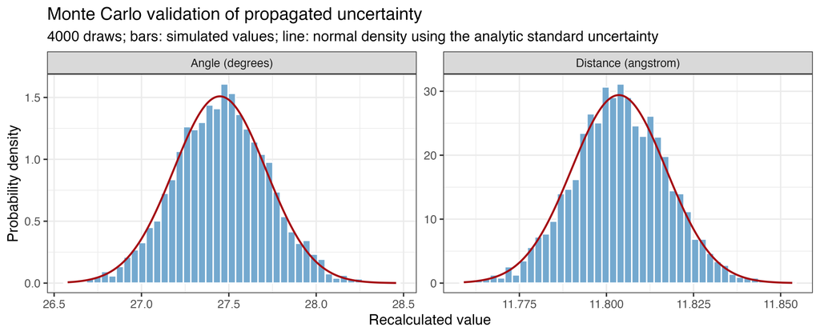

```r
knitr::include_graphics(file.path(validation_dir, "monte_carlo_validation.png"))
```

The observed relative differences are approximately 0.30% for distance and 0.40% for angle. These results support the first-order calculation for this non-collinear triclinic example and the stated input distributions. They do not recover unavailable refinement covariance or establish accuracy for every CIF, near-singular angle, or uncertainty magnitude.

## Publication Figures

```r
source("../scripts/export_publication_figures.R")
export_mineral_publication_figures(list(p83=p83, p91=p91, p92=p92, p94=p94, p11=p11),
                                   file.path(params$output_dir, "publication"))
```